# Appendix

Aaron

2023-08-31

# Data preview

| 1 | 2 | 3 | 4 | 5 | 6 | 7 |
| --- | --- | --- | --- | --- | --- | --- |
| S53A | 1386 km | 7038.6 | 11 dB | 20 wpm | 0837z 21 Dec | horizontal |
| SE5E | 1380 km | 7038.6 | 14 dB | 21 wpm | 0837z 21 Dec | horizontal |
| DL8LAS | 799 km | 7038.6 | 6 dB | 21 wpm | 0838z 21 Dec | horizontal |
| DM7EE | 828 km | 7038.6 | 11 dB | 21 wpm | 0838z 21 Dec | horizontal |

The meaning of each column of indicators can be determined through Google search and speculation

Copy data from ODS files to a new XLSX file, and read the file through the following code:

## loading packages and reading data

```r
# loading packages --------------------------------------------------------

## Cleaning Data Packages
library(tidyverse)
## Reading XLSX file Packages
library(openxlsx)
## Clean Date
library(lubridate)

library(car)
library(ggpubr)
library(rstatix)

## Set Date format zone
Sys.setlocale(locale = 'EN')
```

```
## [1] "LC_COLLATE=EN;LC_CTYPE=EN;LC_MONETARY=EN;LC_NUMERIC=C;LC_TIME=EN"
```

```r
# reading data ------------------------------------------------------------

DataRaw <- read.xlsx('./Appendix_1 Raw Data.xlsx')
## The type of DataRaw
str(DataRaw)
```

```
## 'data.frame':    2586 obs. of  8 variables:
##  $ ID       : chr  "  S53A" "  SE5E" "  DL8LAS" "  DM7EE" ...
##  $ Distance : chr  "1386 km" "1380 km" "799 km" "828 km" ...
##  $ Frequency: chr  "7038.6" "7038.6" "7038.6" "7038.6" ...
##  $ SNR      : chr  "11 dB" "14 dB" "6 dB" "11 dB" ...
##  $ Speed    : chr  "20 wpm" "21 wpm" "21 wpm" "21 wpm" ...
##  $ Time     : chr  "0837z 21 Dec" "0837z 21 Dec" "0838z 21 Dec" "0838z 21 Dec" ...
##  $ year     : num  2022 2022 2022 2022 2022 ...
##  $ Type     : chr  "horizontal" "horizontal" "horizontal" "horizontal" ...
```

```r
## The hand of DataRaw
head(DataRaw)
```

```
##                ID       Distance Frequency   SNR  Speed         Time year
## 1     S53A 1386 km    7038.6 11 dB 20 wpm 0837z 21 Dec 2022
## 2     SE5E 1380 km    7038.6 14 dB 21 wpm 0837z 21 Dec 2022
## 3   DL8LAS  799 km    7038.6  6 dB 21 wpm 0838z 21 Dec 2022
## 4    DM7EE  828 km    7038.6 11 dB 21 wpm 0838z 21 Dec 2022
## 5    OH6BG 1750 km    7038.6 16 dB 21 wpm 0838z 21 Dec 2022
## 6   SM7IUN  996 km    7038.6 11 dB 21 wpm 0838z 21 Dec 2022
##         Type
## 1 horizontal
## 2 horizontal
## 3 horizontal
## 4 horizontal
## 5 horizontal
## 6 horizontal
```

## The problem of raw data

The raw data cannot meet the requirements. By running the code, you can find some problems

1. ID column: Spaces in the text
2. Distance column: Contains units
3. Frequency column: The class of column is the character, not the number or integer
4. SNR column: contains units
5. Speed column: Also contains units
6. Time column: The class of column is a character too, and the format is “%H%M %d %b”
7. Type column: Sees OK, but this column have 3 elements: `"horizontal" "magloop" "horizontal qro"`

# Data cleaning

```r
## Time extract to year, month, day and Periods (0-6, 7-11, 12-15, 18-24).
DataClean <- DataRaw |>
  mutate(ID = str_remove_all(ID, "\\s+"),
         Distance = as.numeric(str_remove_all(Distance, "\\D")),
         Frequency = as.numeric(Frequency),
         SNR = as.numeric(str_remove_all(SNR, "\\D")),
         ## horizontal qro is a type of Antenna orientation
         # Type = str_remove_all(Type, " qro"),
         Speed = as.numeric(str_remove_all(Speed, "\\D"))) |>
  mutate(Time = str_remove(Time, 'z'),
         Time = paste(substr(Time, 1, 2), substr(Time, 3, nchar(Time))),
         Time = paste(Time, year), ## Suppose all data was collected in 2022
         Time = as.POSIXct(Time, format = "%H %M %d %b %Y")) |>
  ## Time extract to year, month, day and Periods, Facilitate subsequent analysis of the impact of time on SNR
  mutate(month = month(Time),
         day = day(Time),
         hour = hour(Time),
         periods = if_else(hour >= 18, "Evening",
                      if_else(hour >= 12, "Afternoon",
                             if_else(hour >= 6, "Morning", "Early morning"))),
         season = if_else(month >= 12 | month <= 2, "Winter",
                          if_else(month >= 6 & month <= 8, "Summer",
                                  if_else(month >= 9 & month <= 11, "Autumn", "Spring"))
                          ),
         season = factor(season,
                         levels = c("Summer", "Winter")))
DataClean$Type[DataClean$Type == "horizontal"] <- "Horizontal Antenna"
DataClean$Type[DataClean$Type == "horizontal QRO"] <- "Horizontal Antenna (QRO)"
DataClean$Type[DataClean$Type == "horizontal qro"] <- "Horizontal Antenna (QRO)"
DataClean$Type[DataClean$Type == "magloop"] <- "Magnetic Loop Antenna"

head(DataClean)
```

```
##       ID Distance Frequency SNR Speed                Time year
## 1   S53A     1386    7038.6  11    20 2022-12-21 08:37:00 2022
## 2   SE5E     1380    7038.6  14    21 2022-12-21 08:37:00 2022
## 3 DL8LAS      799    7038.6   6    21 2022-12-21 08:38:00 2022
## 4  DM7EE      828    7038.6  11    21 2022-12-21 08:38:00 2022
## 5  OH6BG     1750    7038.6  16    21 2022-12-21 08:38:00 2022
## 6 SM7IUN      996    7038.6  11    21 2022-12-21 08:38:00 2022
##                 Type month day hour periods season
## 1 Horizontal Antenna    12  21    8 Morning Winter
## 2 Horizontal Antenna    12  21    8 Morning Winter
## 3 Horizontal Antenna    12  21    8 Morning Winter
## 4 Horizontal Antenna    12  21    8 Morning Winter
## 5 Horizontal Antenna    12  21    8 Morning Winter
## 6 Horizontal Antenna    12  21    8 Morning Winter
```

## Check all columns of data

```r
# table(DataClean$ID)
ValueCheckID <- DataClean$ID |>
  grepl(pattern = "[^A-Za-z0-9]")

if (any(ValueCheckID)) {
  warning(paste("ID contains unexpected values, please check carefully!"))
  print(DataClean[which(ValueCheckID),])
}
```

**Warning** ID contains unexpected values, please check carefully!

```
##                                            ID Distance Frequency SNR Speed
## 365  https://reversebeacon.net/qrz/rbn/MM0ZBH      385    7029.5  21    20
## 395                                  EA2RCF-4     1106    7030.4   2    20
## 485                                    W1NT-6     5100   14034.1  23    21
## 490                                    W1NT-2     5100   14034.1  17    20
## 536                                   DK9IP-1      813    7031.2   9    21
## 564                                  EA2RCF-4     1106    7026.1   5    20
## 617                                    KM3T-2     5140   14027.2   4    21
## 626                                    W1NT-6     5100   14027.2  11    21
## 669                                    KM3T-3     5140   14025.1   5    21
## 694                                    W1NT-6     5100   14025.1  20    20
## 696                                    W1NT-2     5100   14025.1  16    21
## 702                                   DK9IP-1      813   14031.2  10    21
## 804                                   DK9IP-1      813    7028.4  13    20
## 816                                   DK9IP-1      813    7026.8   5    22
```

[output cut: 219 more lines]

```r
DataClean[DataClean$ID == "https://reversebeacon.net/qrz/rbn/MM0ZBH", "ID"] <- "MM0ZBH"
DataClean$ID <- str_remove_all(DataClean$ID, "-.*")
write.csv(unique(DataClean$ID), file = './station.csv', quote = F)

DataClean[DataClean$Type == "horizontal qro", "Type"] <- "horizontal QRO"
```

```r
summary(DataClean$Distance)
```

```
##    Min. 1st Qu.  Median    Mean 3rd Qu.    Max.
##     102     799    1076    1239    1440    9541
```

```r
summary(DataClean$Frequency)
```

```
##    Min. 1st Qu.  Median    Mean 3rd Qu.    Max.
##    7012    7029    7036   10320   14028   14038
```

```r
summary(DataClean$Power)
```

```
## Length  Class   Mode
##      0   NULL   NULL
```

```r
summary(DataClean$Speed)
```

```
##    Min. 1st Qu.  Median    Mean 3rd Qu.    Max.
##   14.00   21.00   21.00   20.95   21.00   30.00
```

```r
summary(DataClean$Type)
```

```
##    Length     Class      Mode
##      2586 character character
```

```r
table(DataClean$Type)
```

```
##
##       Horizontal Antenna Horizontal Antenna (QRO)    Magnetic Loop Antenna
##                      866                     1032                      688
```

```r
summary(DataClean$Time)
```

```
##                       Min.                    1st Qu.
## "2022-12-18 13:09:00.0000" "2023-08-04 09:31:00.0000"
##                     Median                       Mean
## "2023-08-06 10:04:00.0000" "2023-06-26 01:47:18.9327"
##                    3rd Qu.                       Max.
## "2023-08-08 11:59:00.0000" "2023-08-08 22:33:00.0000"
```

## Location

```r
library(geosphere)
library(leaflet)
```

setting the location of London, and calculate the oriention of station.

```r
DataLocation <- read.xlsx('./Appendix_3 Update Station Location.xlsx')
LondonLocation <- c(51.5072, -0.1276)

DataLocation$Direction1[DataLocation$Longitude < LondonLocation[2]] <- "W"
DataLocation$Direction1[DataLocation$Longitude > LondonLocation[2]] <- "E"
DataLocation$Direction2[DataLocation$Latitude < LondonLocation[1]] <- "S"
DataLocation$Direction2[DataLocation$Latitude > LondonLocation[1]] <- "N"

# DataLocation <- DataLocation[,c("x", "Direction1", "Direction2")]

DataLocation$Direction2[DataLocation$Direction2 == "N"] <- "North"
DataLocation$Direction2[DataLocation$Direction2 == "S"] <- "South"
DataLocation$Direction1[DataLocation$Direction1 == "E"] <- "East"
DataLocation$Direction1[DataLocation$Direction1 == "W"] <- "West"


DataLocation <- DataLocation |>
  mutate(Location = paste(Direction2, Direction1, sep = '-'))

DataClean <- DataClean |>
  left_join(DataLocation, by = c(ID = 'x'))

DataMap <- DataClean |>
  group_by(ID, Latitude, Longitude) |>
  count() |>
  mutate(
    color = cut(n,
                breaks = c(0, 10, 30, 100),
                labels = c('green', 'navy', 'red')),
    radius = cut(n,
                 breaks = c(0, 10, 30, 100),
                 labels = c(3, 7, 10))
  )

# leaflet() |>
#   addTiles() |>
#   addMarkers(data = DataLocation,
#              lat = ~Latitude,
#              lng = ~Longitude) |>
#   addCircleMarkers(lat = LondonLocation[1],
#                    lng = LondonLocation[2],
#                    color = "red",
#                    radius = 8)
leaflet() |>
  addTiles() |>
  addCircleMarkers(data = DataMap,
                   lng = ~Longitude,
                   lat = ~Latitude,
                   radius = ~as.numeric(as.character(radius)),
                   color = ~color,
                   stroke = F,
                   fillOpacity = 0.8) |>
  addMarkers(lat = LondonLocation[1],
             lng = LondonLocation[2])
```

Warning in validateCoords(lng, lat, funcName): Data contains 7 rows with either

missing or invalid lat/lon values and will be ignored

[interactive chart not shown]

Table 2.

|  | North-East (N=32) | North-West (N=8) | South-East (N=49) | South-West (N=22) | Total (N=111) | p value |
| --- | --- | --- | --- | --- | --- | --- |
| **Distance, km** |  |  |  |  |  | < 0.01<sup>1</sup> |
| Mean (SD) | 1429 (972) | 646 (724) | 1848 (2241) | 3656 (2573) | 1999 (2131) |  |
| Range | 169 - 3888 | 122 - 1885 | 427 - 9541 | 102 - 8628 | 102 - 9541 |  |
| **Distance Group, km** |  |  |  |  |  | < 0.01<sup>2</sup> |
| (0,500] | 7 (21.9%) | 6 (75.0%) | 3 (6.1%) | 3 (13.6%) | 19 (17.1%) |  |
| (500,1e+03] | 8 (25.0%) | 0 (0.0%) | 14 (28.6%) | 0 (0.0%) | 22 (19.8%) |  |
| (1e+03,1.3e+03] | 1 (3.1%) | 0 (0.0%) | 12 (24.5%) | 4 (18.2%) | 17 (15.3%) |  |
| (1.3e+03,3e+03] | 14 (43.8%) | 2 (25.0%) | 16 (32.7%) | 3 (13.6%) | 35 (31.5%) |  |
| (3e+03,1e+04] | 2 (6.2%) | 0 (0.0%) | 4 (8.2%) | 12 (54.5%) | 18 (16.2%) |  |

1. Linear Model ANOVA
2. Pearson’s Chi-squared test

Most stations are located in the European region at the east of London.

# Pre-analysis

Table 1.

|  | Horizontal Antenna (N=866) | Horizontal Antenna (QRO) (N=1032) | Magnetic Loop Antenna (N=688) | Total (N=2586) |
| --- | --- | --- | --- | --- |
| **Oriention** |  |  |  |  |
| North-East | 239 (27.6%) | 266 (25.8%) | 199 (28.9%) | 704 (27.2%) |
| North-West | 102 (11.8%) | 95 (9.2%) | 77 (11.2%) | 274 (10.6%) |
| South-East | 428 (49.4%) | 527 (51.1%) | 340 (49.4%) | 1295 (50.1%) |
| South-West | 97 (11.2%) | 144 (14.0%) | 72 (10.5%) | 313 (12.1%) |
| **Distance, km** |  |  |  |  |
| Mean (SD) | 1164 (831) | 1422 (1271) | 1056 (736) | 1239 (1022) |
| Range | 122 - 8408 | 102 - 9541 | 130 - 8408 | 102 - 9541 |
| **Distance Group, km** |  |  |  |  |
| (0,500] | 166 (19.2%) | 128 (12.4%) | 162 (23.5%) | 456 (17.6%) |
| (500,1e+03] | 226 (26.1%) | 255 (24.7%) | 149 (21.7%) | 630 (24.4%) |
| (1e+03,1.3e+03] | 161 (18.6%) | 222 (21.5%) | 158 (23.0%) | 541 (20.9%) |
| (1.3e+03,3e+03] | 290 (33.5%) | 358 (34.7%) | 211 (30.7%) | 859 (33.2%) |
| (3e+03,1e+04] | 23 (2.7%) | 69 (6.7%) | 8 (1.2%) | 100 (3.9%) |
| **Speed, words per minute** |  |  |  |  |
| Mean (SD) | 21 (1) | 21 (1) | 21 (1) | 21 (1) |
| Range | 19 - 23 | 14 - 30 | 19 - 23 | 14 - 30 |
| **SNR, dB** |  |  |  |  |
| Mean (SD) | 11 (6) | 14 (7) | 10 (6) | 12 (7) |
| Range | 1 - 33 | 1 - 43 | 1 - 39 | 1 - 43 |
| **Periods of Day** |  |  |  |  |
| Afternoon | 373 (43.1%) | 389 (37.7%) | 287 (41.7%) | 1049 (40.6%) |
| Evening | 264 (30.5%) | 356 (34.5%) | 225 (32.7%) | 845 (32.7%) |
| Morning | 229 (26.4%) | 287 (27.8%) | 176 (25.6%) | 692 (26.8%) |
| **Season** |  |  |  |  |
| Summer | 697 (80.5%) | 915 (88.7%) | 502 (73.0%) | 2114 (81.7%) |
| Winter | 169 (19.5%) | 117 (11.3%) | 186 (27.0%) | 472 (18.3%) |

```r
library(wordcloud)
library(patchwork)
library(viridis)
library(GGally)
```

### Distribution of calls signs

```r
DataSumAll <- DataClean |>
  mutate(Location = paste(Direction2, Direction1, sep = '-')) |>
  group_by(ID, Location) |>
  count() |>
  as.data.frame() |>
  arrange(desc(n)) |>
  mutate(ID = factor(ID, levels = ID))

DataSum <- DataClean |>
  mutate(Location = paste(Direction2, Direction1,  sep = '-')) |>
  group_by(ID, Type, Location) |>
  count() |>
  as.data.frame() |>
  arrange(desc(n)) |>
 mutate(ID = factor(ID, levels = DataSumAll$ID))

head(DataSumAll)
```

```
##       ID   Location  n
## 1   SE5E North-East 94
## 2  DF2CK South-East 82
## 3  G4ZFE South-West 73
## 4 MM0ZBH North-West 65
## 5  G0KTN North-East 63
## 6   S53A South-East 63
```

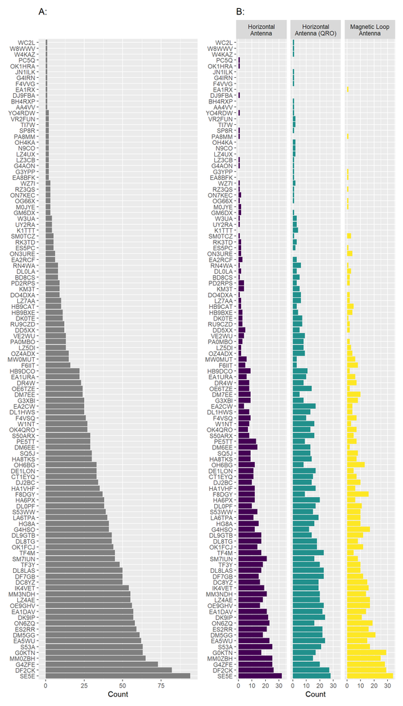

```r
labeltype <- c(
  `Horizontal Antenna` = "Horizontal\nAntenna",
                                 `Magnetic Loop Antenna` = "Magnetic Loop\nAntenna",
                                 `Horizontal Antenna (QRO)` = "Horizontal\nAntenna (QRO)"
)
fig1 <- ggplot(data = DataSumAll) +
  geom_col(mapping = aes(x = ID,
                         y = n),
           fill = 'grey50')+
  scale_fill_viridis_d()+
  coord_flip()+
  labs(title = "A:",
       y = 'Count',
       x = NULL)

fig3 <- ggplot(data = DataSum) +
  geom_col(mapping = aes(x = ID,
                         y = n,
                         fill = Type))+
  scale_fill_viridis_d()+
  coord_flip()+
  facet_grid(.~Type,
             labeller = labeller(Type = labeltype)
             )+
  theme(legend.position = 'none')+
  labs(title = "B:",
       y = 'Count',
       x = NULL)

DataSumAll <- DataSum |>
  select(ID, Type, n) |>
  pivot_wider(names_from = Type,
              values_from = n) |>
  right_join(DataSumAll) |>
  arrange(desc(n))

write.xlsx(DataSumAll,
           file = './Appendix_7 Shortwave Antenna Stations and Sessions Distribution.xlsx')

fig1 + fig3
```

### Distribution of time

```r
DataClean <- DataClean |>
  mutate(md = paste(month, day, sep = "-"))

write.xlsx(DataClean,
           "./Appendix_4 Cleaned Data.xlsx")

DataClean |>
  group_by(season, hour, Type) |>
  count() |>
  pivot_wider(names_from = Type,
              values_from = n,
              values_fill = 0) |>
  mutate(total = `Horizontal Antenna` + `Magnetic Loop Antenna`  +  `Horizontal Antenna (QRO)`) |>
  print(n = 50)
```

```
## # A tibble: 25 x 6
## # Groups:   season, hour [25]
##    season  hour `Horizontal Antenna` `Horizontal Antenna (QRO)` Magnetic~1 total
##    <fct>  <int>                <int>                      <int>      <int> <int>
##  1 Summer     6                   13                         24          7    44
##  2 Summer     7                   43                         52         32   127
##  3 Summer     9                   39                         44         27   110
##  4 Summer    10                   64                         79         40   183
##  5 Summer    11                   17                         28         10    55
##  6 Summer    12                   53                         76         34   163
##  7 Summer    13                   44                         57         30   131
##  8 Summer    14                    8                          5          5    18
##  9 Summer    15                   38                         68         39   145
## 10 Summer    16                   43                         57         28   128
## 11 Summer    17                   81                         86         38   205
## 12 Summer    18                   29                         42         30   101
## 13 Summer    19                   70                         76         42   188
## 14 Summer    20                   87                        157         81   325
## 15 Summer    21                   35                         24         33    92
## 16 Summer    22                   33                         40         26    99
## 17 Winter     8                   25                         29         30    84
## 18 Winter     9                   18                         21         12    51
## 19 Winter    11                   10                         10         18    38
## 20 Winter    12                    4                          0          8    12
## 21 Winter    13                   12                          0         23    35
## 22 Winter    14                   38                         14         30    82
## 23 Winter    15                   14                          0         21    35
## 24 Winter    16                   38                         26         31    95
## 25 Winter    18                   10                         17         13    40
## # ... with abbreviated variable name 1: `Magnetic Loop Antenna`
```

```r
ggplot(DataClean,
       mapping = aes(x = hour,
                     fill = Type)) +
  geom_histogram(binwidth = 1,
                 color = "black") +
  facet_grid(season ~ .,
             scales = "free_x") +
  scale_y_continuous(limits = c(0, 170),
                     expand = c(0, 0))+
  scale_x_continuous(breaks = 5:22) +
  scale_fill_viridis_d()+
  theme_bw() +
  theme(legend.position = 'top') +
  labs(x = "Hour",
       y = "Frequency")
```

**Warning** Removed 5 rows containing missing values (`geom_bar()`).

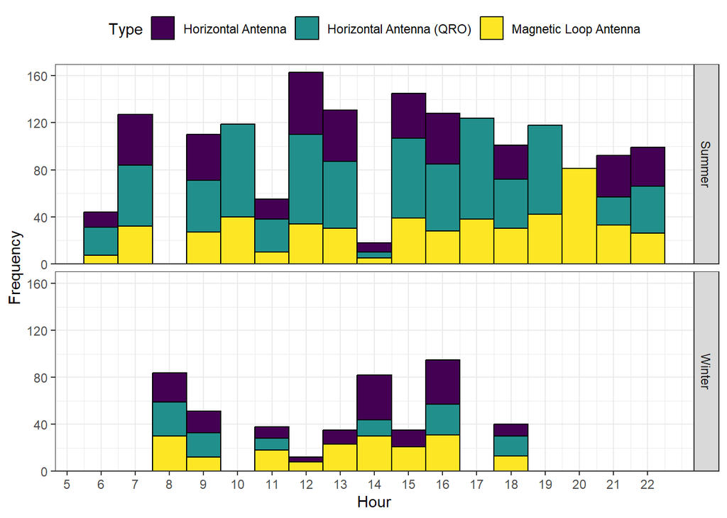

### Distribution of distance

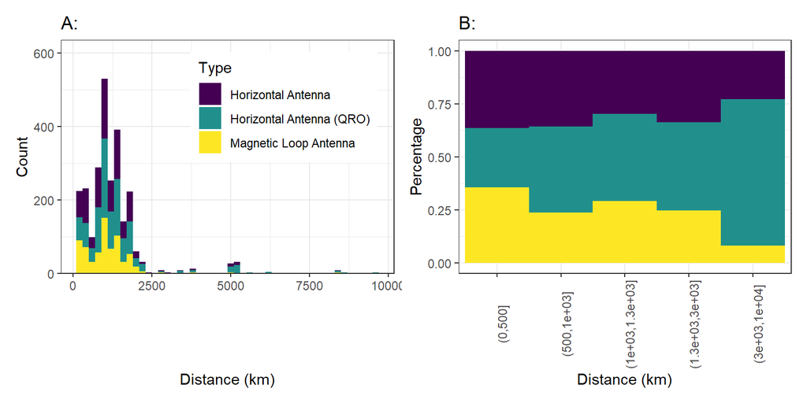

```r
DataSum <- DataClean |>
  mutate(DistanceGroup = cut(Distance,
                             breaks = c(0, 500, 1000, 1300, 3000, 10000)))

fig1 <- ggplot(data = DataClean,
       mapping = aes(x = Distance,
                     fill= Type))+
  geom_histogram(binwidth = 200)+
  scale_fill_viridis_d()+
  scale_y_continuous(expand = expansion(mult = c(0, 0.2)),
                     limits = c(0, NA))+
  theme_bw()+
  theme(legend.position = c(0.95, 0.95),
        legend.justification = c(1, 1))+
  labs(x = "Distance (km)",
       y = "Count",
       title = 'A:')

fig2 <- ggplot(DataSum, aes(x = DistanceGroup,
                    fill = Type)) +
  geom_bar(position = "fill", width = 1)+
  scale_fill_viridis_d()+
  theme_bw()+
  theme(legend.position = "none",
        axis.text.x = element_text(angle = 90))+
  labs(x = "Distance (km)",
       y = "Percentage",
       title = 'B:')

fig1 + fig2
```

```r
DataClean$DistanceToLondon <- distVincentySphere(
  cbind(DataClean$Longitude, DataClean$Latitude),
  cbind(LondonLocation[2], LondonLocation[1])
)/1000

DataClean$Diff <- DataClean$DistanceToLondon - DataClean$Distance

ggplot(data = DataClean,
       mapping = aes(x = Diff,
                     fill= Type))+
  geom_histogram(binwidth = 50)+
  scale_fill_viridis_d()+
  scale_y_continuous(expand = expansion(mult = c(0, 0.2)),
                     limits = c(0, NA))+
  theme_bw()+
  theme(legend.position = c(0.05, 0.95),
        legend.justification = c(0, 1))+
  labs(x = "Distance (km)",
       y = "Count",
       title = 'A:')
```

**Warning** Removed 229 rows containing non-finite values (`stat_bin()`).

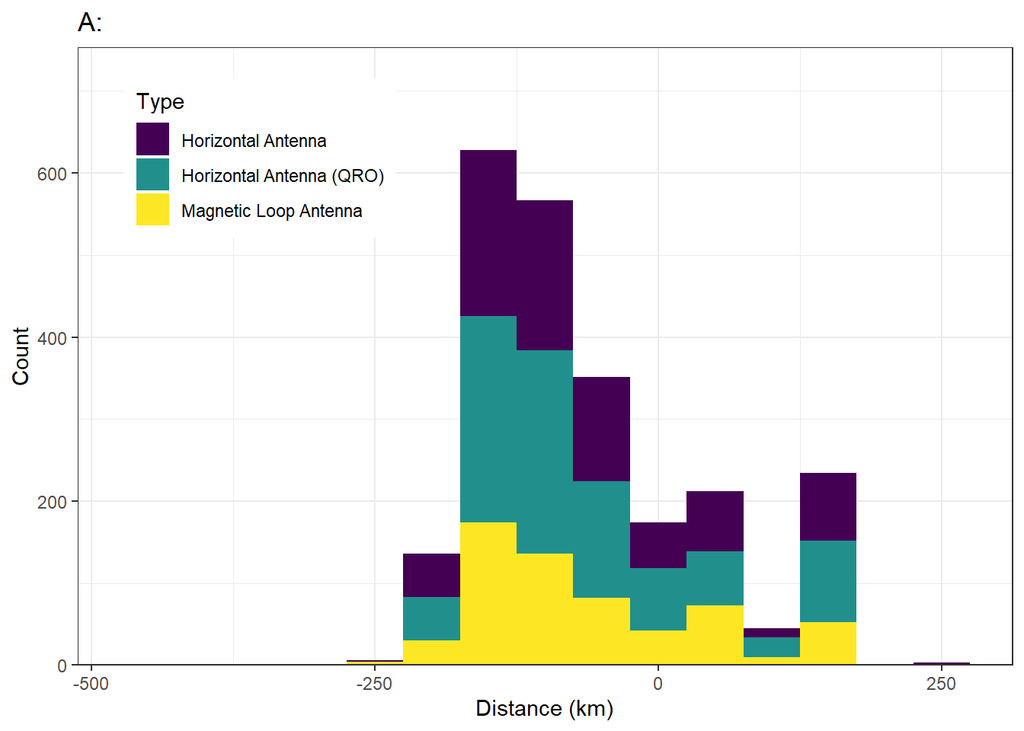

```r
quantile(DataClean$Diff, na.rm = T)
```

```
##         0%        25%        50%        75%       100%
## -448.01392 -130.44912  -92.46718   -4.21162  262.43692
```

```r
t.test(DataClean$Diff)
```

```
##
##  One Sample t-test
##
## data:  DataClean$Diff
## t = -30.543, df = 2356, p-value < 2.2e-16
## alternative hypothesis: true mean is not equal to 0
## 95 percent confidence interval:
##  -66.74718 -58.69338
## sample estimates:
## mean of x
## -62.72028
```

Longitude and latitude of this station maybe error.

```r
ValueOut <- DataClean |>
  filter(Diff < -150 | Diff > 150) |>
  group_by(ID, Diff) |>
  count() |>
  arrange(Diff)
print(ValueOut)
```

```
## # A tibble: 16 x 3
## # Groups:   ID, Diff [16]
##    ID      Diff     n
##    <chr>  <dbl> <int>
##  1 F4VVG  -448.     1
##  2 ON3URE -233.     6
##  3 HG8A   -222.    41
##  4 DM6EE  -194.    29
##  5 IK4VET -188.    54
##  6 DD5XX  -179.    12
##  7 G0KTN  -167.    63
##  8 F4VSQ  -166.    26
##  9 OE9GHV -157.    56
## 10 HB9BXE -157.    11
## 11 HB9DCO -156.    22
## 12 F6IIT  -152.    16
## 13 N9CO    153.     2
## 14 MM0ZBH  163.    65
## 15 TF3Y    170.    48
## 16 GM6DX   262.     3
```

### Distribution of speed

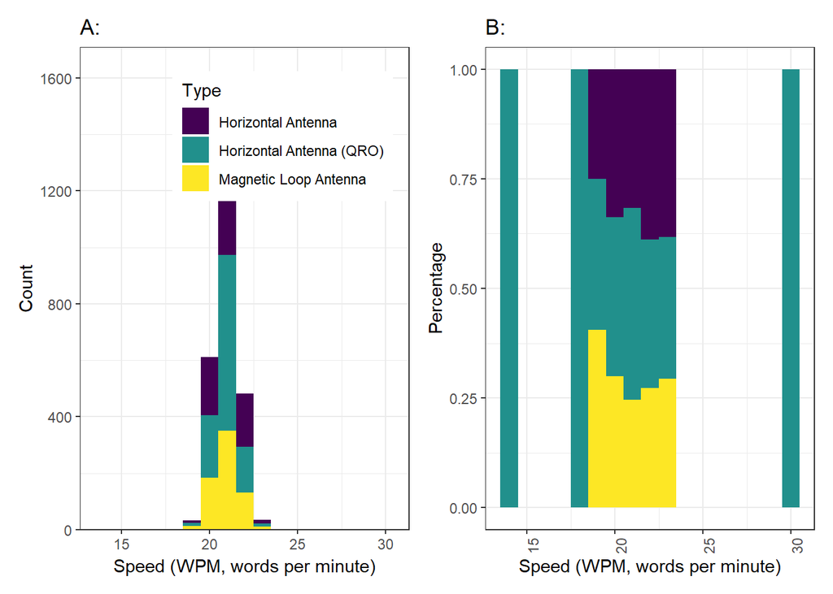

```r
fig1 <- ggplot(data = DataClean,
       mapping = aes(x = Speed,
                     fill= Type))+
  geom_histogram(binwidth = 1)+
  scale_fill_viridis_d()+
  scale_y_continuous(expand = expansion(mult = c(0, 0.2)),
                     limits = c(0, NA))+
  theme_bw()+
  theme(legend.position = c(0.95, 0.95),
        legend.justification = c(1, 1))+
  labs(x = "Speed (WPM, words per minute)",
       y = "Count",
       title = 'A:')

fig2 <- ggplot(DataSum,
               mapping = aes(x = Speed,
                             fill = Type)) +
  geom_bar(position = "fill", width = 1)+
  scale_fill_viridis_d()+
  theme_bw()+
  theme(legend.position = "none",
        axis.text.x = element_text(angle = 90))+
  labs(x = "Speed (WPM, words per minute)",
       y = "Percentage",
       title = 'B:')

fig1 + fig2
```

### Distribution of SNR (Signal-to-Noise Ratio)

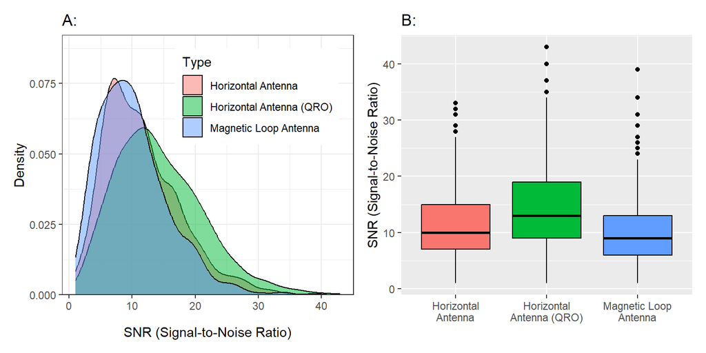

```r
fig1 <- ggplot(data = DataClean)+
  geom_density(mapping = aes(x = SNR,
                             fill = Type),
               alpha = 0.5)+
  scale_color_viridis_d()+
  scale_y_continuous(expand = expansion(mult = c(0, 0.2)),
                     limits = c(0, NA))+
  theme_bw()+
  theme(legend.position = c(0.95, 0.95),
        legend.justification = c(1, 1))+
  labs(x = "SNR (Signal-to-Noise Ratio)",
       y = "Density",
       title = 'A:')

fig2 <- ggplot(DataClean, aes(x = Type, y = SNR, fill = Type)) +
  geom_boxplot(color = "black")+
  scale_x_discrete(labels = labeltype)+
  theme(legend.position = 'none')+
  labs(title = 'B:',
       y = "SNR (Signal-to-Noise Ratio)",
       x = NULL)

fig1 + fig2
```

```r
DataSummary <- DataClean |>
  group_by(Type) |>
  summarise(SNR_Mean = mean(SNR),
            SNR_Median = median(SNR),
            IQR = paste(quantile(SNR, 0.25), quantile(SNR, 0.75), sep = '-'))
print(DataSummary)
```

```
## # A tibble: 3 x 4
##   Type                     SNR_Mean SNR_Median IQR
##   <chr>                       <dbl>      <dbl> <chr>
## 1 Horizontal Antenna           11.4         10 7-15
## 2 Horizontal Antenna (QRO)     14.3         13 9-19
## 3 Magnetic Loop Antenna        10.2          9 6-13
```

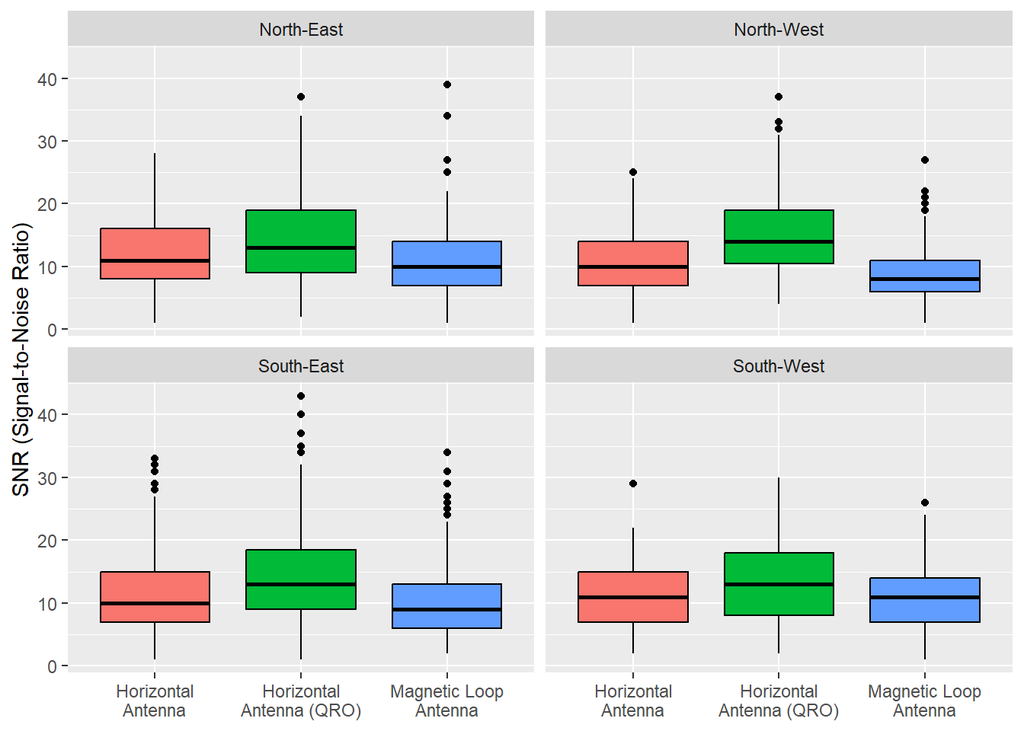

```r
ggplot(DataClean, aes(x = Type, y = SNR, fill = Type)) +
  geom_boxplot(color = "black")+
  facet_wrap(.~Location,
             ncol = 2)+
  scale_x_discrete(labels = labeltype)+
  theme(legend.position = 'none')+
  labs(y = "SNR (Signal-to-Noise Ratio)",
       x = NULL)
```

```r
DataClean |>
  group_by(Location, Type) |>
  summarise(mean = mean(SNR),
            SD = sd(SNR),
            .groups = 'drop')
```

```
## # A tibble: 12 x 4
##    Location   Type                      mean    SD
##    <chr>      <chr>                    <dbl> <dbl>
##  1 North-East Horizontal Antenna       11.6   5.35
##  2 North-East Horizontal Antenna (QRO) 14.4   6.95
##  3 North-East Magnetic Loop Antenna    10.6   5.66
##  4 North-West Horizontal Antenna       10.7   5.40
##  5 North-West Horizontal Antenna (QRO) 15.4   6.87
##  6 North-West Magnetic Loop Antenna     9.16  4.96
##  7 South-East Horizontal Antenna       11.5   6.41
##  8 South-East Horizontal Antenna (QRO) 14.3   7.12
##  9 South-East Magnetic Loop Antenna    10.1   5.66
## 10 South-West Horizontal Antenna       11.4   5.56
## 11 South-West Horizontal Antenna (QRO) 13.3   6.27
## 12 South-West Magnetic Loop Antenna    10.9   5.65
```

# Statistical analysis

## Relation between values

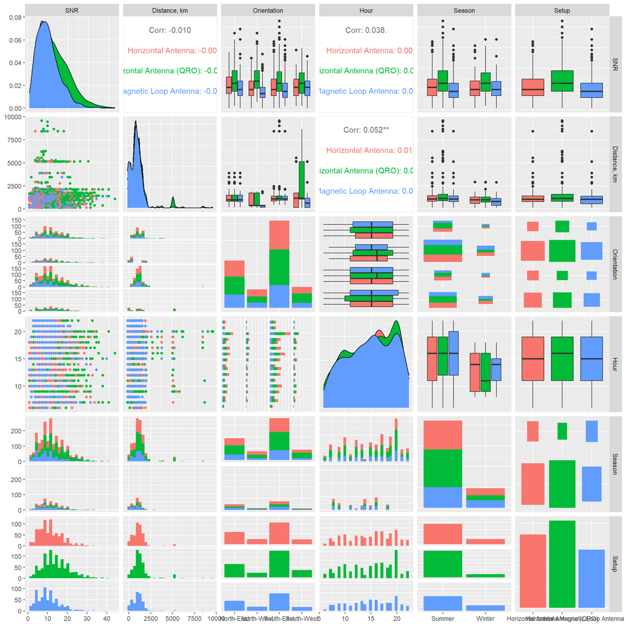

```r
## Dummy variable
DataClean <- DataClean |>
  mutate(TypeQro = if_else(Type == 'Horizontal Antenna (QRO)', 1, 0),
         TypeMag = if_else(Type == 'Magnetic Loop Antenna', 1, 0),
         DistanceGroup = cut(Distance,
                             breaks = c(0, 500, 1000, 1300, 3000, 10000)))

ggpairs(data = DataClean[,c("SNR", "Distance", "Location", "hour", "season", "Type")],
        mapping = aes(color = Type),
        columnLabels = c("SNR", "Distance, km", "Orientation", "Hour", "Season", "Setup"),
        alpha = 0.5)
```

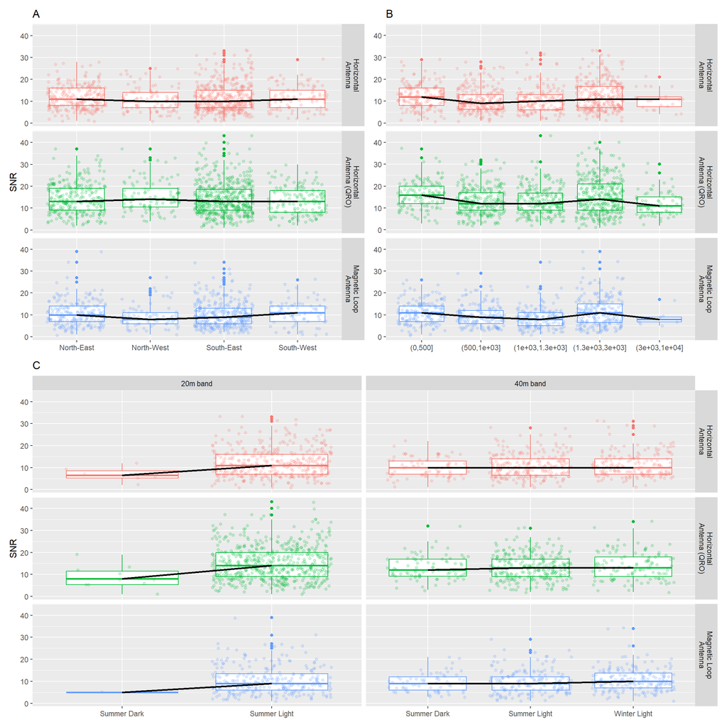

```r
DataClean <- DataClean |>
  mutate(stage = if_else(hour < 7 | hour >20,
                         "Dark", "Light"),
         FrequencyGroup = if_else(Frequency < 10000,
                                  "40m band",
                                  "20m band"))
fig1 <- ggplot(data = DataClean) +
  geom_boxplot(mapping = aes(x = Location,
                             y = SNR,
                             group = Location,
                             color = Type))+
  geom_jitter(mapping = aes(x = Location,
                          y = SNR,
                          group = Location,
                          color = Type),
               alpha = 0.2)+
  geom_line(mapping = aes(x = Location,
                          y = SNR,
                          group = Type),
            stat = "summary",
            fun.data = function(x) {
              y <- median(x)
              data.frame(y = y)
            },
            size = 1) +
  facet_grid(Type~.,
             labeller = labeller(Type = labeltype)) +
  labs(x = NULL,
       title = "A")

fig2 <- ggplot(data = DataClean) +
  geom_boxplot(mapping = aes(x = DistanceGroup,
                             y = SNR,
                             group = DistanceGroup,
                             color = Type))+
  geom_jitter(mapping = aes(x = DistanceGroup,
                          y = SNR,
                          group = DistanceGroup,
                          color = Type),
               alpha = 0.2)+
  geom_line(mapping = aes(x = DistanceGroup,
                          y = SNR,
                          group = Type),
            stat = "summary",
            fun.data = function(x) {
              y <- median(x)
              data.frame(y = y)
            },
            size = 1) +
  facet_grid(Type~.,
             labeller = labeller(Type = labeltype)) +
  labs(x = NULL,
       title = "B",
       y = NULL)

fig3 <- ggplot(data = DataClean) +
  geom_boxplot(mapping = aes(x = paste(season, stage),
                             y = SNR,
                             group = paste(season, stage),
                             color = Type))+
  geom_jitter(mapping = aes(x = paste(season, stage),
                          y = SNR,
                          group = paste(season, stage),
                          color = Type),
               alpha = 0.2)+
  geom_line(mapping = aes(x = paste(season, stage),
                          y = SNR,
                          group = Type),
            stat = "summary",
            fun.data = function(x) {
              y <- median(x)
              data.frame(y = y)
            },
            size = 1) +
  facet_grid(Type~FrequencyGroup,
             scales = "free_x",
             labeller = labeller(Type = labeltype)) +
  labs(x = NULL,
       title = "C")


(fig1 + fig2) / fig3 &
  theme(legend.position = 'none')
```

```r
DataClean |>
  group_by(Type, Location) |>
  summarize(median = median(SNR),
            Q1 = quantile(SNR, 0.25),
            Q3 = quantile(SNR, 0.75))
```

`summarise()` has grouped output by ‘Type’. You can override using the

`.groups` argument.

```
## # A tibble: 12 x 5
## # Groups:   Type [3]
##    Type                     Location   median    Q1    Q3
##    <chr>                    <chr>       <dbl> <dbl> <dbl>
##  1 Horizontal Antenna       North-East     11   8    16
##  2 Horizontal Antenna       North-West     10   7    14
##  3 Horizontal Antenna       South-East     10   7    15
##  4 Horizontal Antenna       South-West     11   7    15
##  5 Horizontal Antenna (QRO) North-East     13   9    19
##  6 Horizontal Antenna (QRO) North-West     14  10.5  19
##  7 Horizontal Antenna (QRO) South-East     13   9    18.5
##  8 Horizontal Antenna (QRO) South-West     13   8    18
##  9 Magnetic Loop Antenna    North-East     10   7    14
## 10 Magnetic Loop Antenna    North-West      8   6    11
## 11 Magnetic Loop Antenna    South-East      9   6    13
## 12 Magnetic Loop Antenna    South-West     11   7    14
```

```r
DataClean |>
  group_by(Type, DistanceGroup) |>
  summarize(median = median(SNR),
            Q1 = quantile(SNR, 0.25),
            Q3 = quantile(SNR, 0.75))
```

`summarise()` has grouped output by ‘Type’. You can override using the

`.groups` argument.

```
## # A tibble: 15 x 5
## # Groups:   Type [3]
##    Type                     DistanceGroup   median    Q1    Q3
##    <chr>                    <fct>            <dbl> <dbl> <dbl>
##  1 Horizontal Antenna       (0,500]             12  8     16
##  2 Horizontal Antenna       (500,1e+03]          9  6.25  13
##  3 Horizontal Antenna       (1e+03,1.3e+03]     10  6     13
##  4 Horizontal Antenna       (1.3e+03,3e+03]     11  7     16.8
##  5 Horizontal Antenna       (3e+03,1e+04]       11  7.5   12
##  6 Horizontal Antenna (QRO) (0,500]             16 12     20
##  7 Horizontal Antenna (QRO) (500,1e+03]         12  9     17
##  8 Horizontal Antenna (QRO) (1e+03,1.3e+03]     12  9     16.8
##  9 Horizontal Antenna (QRO) (1.3e+03,3e+03]     14  9     21
## 10 Horizontal Antenna (QRO) (3e+03,1e+04]       11  8     15
## 11 Magnetic Loop Antenna    (0,500]             11  7     14
## 12 Magnetic Loop Antenna    (500,1e+03]          9  6     12
## 13 Magnetic Loop Antenna    (1e+03,1.3e+03]      8  5     11
## 14 Magnetic Loop Antenna    (1.3e+03,3e+03]     11  6.5   15
## 15 Magnetic Loop Antenna    (3e+03,1e+04]        8  6.75   9
```

```r
DataClean |>
  group_by(FrequencyGroup, Type, season_stage = paste(season, stage)) |>
  summarize(median = median(SNR),
            Q1 = quantile(SNR, 0.25),
            Q3 = quantile(SNR, 0.75))
```

`summarise()` has grouped output by ‘FrequencyGroup’, ‘Type’. You can override

using the `.groups` argument.

```
## # A tibble: 15 x 6
## # Groups:   FrequencyGroup, Type [6]
##    FrequencyGroup Type                     season_stage median    Q1    Q3
##    <chr>          <chr>                    <chr>         <dbl> <dbl> <dbl>
##  1 20m band       Horizontal Antenna       Summer Dark     6.5  5.25   8.5
##  2 20m band       Horizontal Antenna       Summer Light   11    7     16
##  3 20m band       Horizontal Antenna (QRO) Summer Dark     8    5.25  11.5
##  4 20m band       Horizontal Antenna (QRO) Summer Light   14    9     20
##  5 20m band       Magnetic Loop Antenna    Summer Dark     5    5      5
##  6 20m band       Magnetic Loop Antenna    Summer Light    9    6     13.5
##  7 40m band       Horizontal Antenna       Summer Dark    10    7     13
##  8 40m band       Horizontal Antenna       Summer Light   10    6.5   14
##  9 40m band       Horizontal Antenna       Winter Light   10    7     14
## 10 40m band       Horizontal Antenna (QRO) Summer Dark    12    9.25  17
## 11 40m band       Horizontal Antenna (QRO) Summer Light   13    9     17
## 12 40m band       Horizontal Antenna (QRO) Winter Light   13    9     18
## 13 40m band       Magnetic Loop Antenna    Summer Dark     9    6     12
## 14 40m band       Magnetic Loop Antenna    Summer Light    9    6     12
## 15 40m band       Magnetic Loop Antenna    Winter Light   10    7     13.8
```

## Comparsion analysis of varied antenna orientation

### Check the distribution of data

```r
shapiro.test(DataClean$SNR[DataClean$Type == "Horizontal Antenna"])
```

```
##
##  Shapiro-Wilk normality test
##
## data:  DataClean$SNR[DataClean$Type == "Horizontal Antenna"]
## W = 0.9467, p-value < 2.2e-16
```

```r
shapiro.test(DataClean$SNR[DataClean$Type == "Magnetic Loop Antenna"])
```

```
##
##  Shapiro-Wilk normality test
##
## data:  DataClean$SNR[DataClean$Type == "Magnetic Loop Antenna"]
## W = 0.93649, p-value < 2.2e-16
```

```r
shapiro.test(DataClean$SNR[DataClean$Type == "Horizontal Antenna (QRO)"])
```

```
##
##  Shapiro-Wilk normality test
##
## data:  DataClean$SNR[DataClean$Type == "Horizontal Antenna (QRO)"]
## W = 0.96595, p-value = 8.232e-15
```

```r
leveneTest(SNR ~ Type,
           data = DataClean)
```

Warning in leveneTest.default(y = y, group = group, …): group coerced to

factor.

```
## Levene's Test for Homogeneity of Variance (center = median)
##         Df F value    Pr(>F)
## group    2  20.227 1.922e-09 ***
##       2583
## ---
## Signif. codes:  0 '***' 0.001 '**' 0.01 '*' 0.05 '.' 0.1 ' ' 1
```

## Unadjust

```r
DataClean$Type <- as.factor(DataClean$Type)
anova_test(SNR ~ Type + FrequencyGroup,
           data = DataClean)
```

```
## ANOVA Table (type II tests)
##
##           Effect DFn  DFd      F        p p<.05   ges
## 1           Type   2 2582 88.153 9.25e-38     * 0.064
## 2 FrequencyGroup   1 2582 28.359 1.09e-07     * 0.011
```

```r
DataCopy <- DataClean |>
  mutate(Type = as.character(Type)) |>
  select(Type, SNR, FrequencyGroup)

stat.test.higher <- t_test(SNR ~ Type,
                    data = DataCopy[DataCopy$FrequencyGroup == "20m band",],
                    comparisons = list(c("Horizontal Antenna", "Horizontal Antenna (QRO)"),
                                       c("Horizontal Antenna", "Magnetic Loop Antenna")),
                    p.adjust.method = "none") |>
  add_significance() |>
  add_xy_position(x = "Type")

stat.test.lower <- t_test(SNR ~ Type,
                    data = DataCopy[DataCopy$FrequencyGroup == "40m band",],
                    comparisons = list(c("Horizontal Antenna", "Horizontal Antenna (QRO)"),
                                       c("Horizontal Antenna", "Magnetic Loop Antenna")),
                    p.adjust.method = "none") |>
  add_significance() |>
  add_xy_position(x = "Type")

stat.test.higher$p <- "p < 0.001"
stat.test.lower$p <- c("p < 0.001", "p = 0.042")
stat.test.higher$xmax <- 2
stat.test.lower$xmax <- 2
stat.test.higher$y.position <- stat.test.higher$y.position - 10
stat.test.lower$y.position <- stat.test.lower$y.position - 10

stat.test.higher
```

```
## # A tibble: 2 x 14
##   .y.   group1    group2    n1    n2 stati~1    df p       p.adj p.adj~2 y.pos~3
##   <chr> <chr>     <chr>  <int> <int>   <dbl> <dbl> <chr>   <dbl> <chr>     <dbl>
## 1 SNR   Horizont~ Horiz~   387   565   -6.13  914. p < ~ 1.33e-9 ****       34.2
## 2 SNR   Horizont~ Magne~   387   264    3.60  573. p < ~ 3.5 e-4 ***        36.6
## # ... with 3 more variables: groups <list>, xmin <dbl>, xmax <dbl>, and
## #   abbreviated variable names 1: statistic, 2: p.adj.signif, 3: y.position
```

```r
stat.test.lower
```

```
## # A tibble: 2 x 14
##   .y.   group1   group2    n1    n2 stati~1    df p        p.adj p.adj~2 y.pos~3
##   <chr> <chr>    <chr>  <int> <int>   <dbl> <dbl> <chr>    <dbl> <chr>     <dbl>
## 1 SNR   Horizon~ Horiz~   479   467   -7.09  937. p < ~ 2.67e-12 ****       24.4
## 2 SNR   Horizon~ Magne~   479   424    2.03  897. p = ~ 4.2 e- 2 *          25.1
## # ... with 3 more variables: groups <list>, xmin <dbl>, xmax <dbl>, and
## #   abbreviated variable names 1: statistic, 2: p.adj.signif, 3: y.position
```

```r
mean(DataClean$SNR[DataClean$Type == "Horizontal Antenna" & DataClean$FrequencyGroup == "40m band"])
```

```
## [1] 10.762
```

```r
mean(DataClean$SNR[DataClean$Type == "Horizontal Antenna" & DataClean$FrequencyGroup == "20m band"])
```

```
## [1] 12.2584
```

```r
mean(DataClean$SNR[DataClean$Type == "Magnetic Loop Antenna"& DataClean$FrequencyGroup == "40m band"] )
```

```
## [1] 10.05425
```

```r
mean(DataClean$SNR[DataClean$Type == "Magnetic Loop Antenna"& DataClean$FrequencyGroup == "20m band"] )
```

```
## [1] 10.42803
```

```r
mean(DataClean$SNR[DataClean$Type == "Horizontal Antenna (QRO)" & DataClean$FrequencyGroup == "40m band"])
```

```
## [1] 13.31478
```

```r
mean(DataClean$SNR[DataClean$Type == "Horizontal Antenna (QRO)" & DataClean$FrequencyGroup == "20m band"])
```

```
## [1] 15.09204
```

```r
t.test(DataClean$SNR[DataClean$Location == "North-West" & DataClean$Type == "Horizontal Antenna (QRO)"],
       DataClean$SNR[DataClean$Location == "North-West" & DataClean$Type == "Horizontal Antenna"])
```

```
##
##  Welch Two Sample t-test
##
## data:  DataClean$SNR[DataClean$Location == "North-West" & DataClean$Type == "Horizontal Antenna (QRO)"] and DataClean$SNR[DataClean$Location == "North-West" & DataClean$Type == "Horizontal Antenna"]
## t = 5.2697, df = 178.3, p-value = 3.913e-07
## alternative hypothesis: true difference in means is not equal to 0
## 95 percent confidence interval:
##  2.916997 6.409525
## sample estimates:
## mean of x mean of y
##  15.37895  10.71569
```

## Paired sample

### Horizontal Antenna and Magnetic Loop Antenna

```r
DataSub <- DataClean |>
  arrange(ID, Time) |>
  dplyr::filter(Type %in% c("Horizontal Antenna", "Magnetic Loop Antenna"))

DataSub$pair <- NA

time_window <- 2

pair_counter <- 1
for (i in 2:nrow(DataSub)) {
  ## Same ID, Samilar time and varied type
  if (DataSub$ID[i] == DataSub$ID[i - 1] &&
      difftime(DataSub$Time[i], DataSub$Time[i - 1], units = "hours") <= time_window &&
      DataSub$Type[i] != DataSub$Type[i - 1]) {
    DataSub$pair[i] <- pair_counter
    DataSub$pair[i - 1] <- pair_counter
    pair_counter <- pair_counter + 1
  }
}

fig1 <- ggboxplot(data = DataSub[DataSub$FrequencyGroup == "20m band",],
                 x = "Type",
                 y = "SNR",
                 color = "Type",
                 palette = 'Viridis',
                 add = 'jitter',
                 ggtheme = theme_bw(),
                 legend='none',
                 xlab = "",
                 ylab = 'SNR',
                 title = 'A') +
  stat_pvalue_manual(stat.test.higher[2,],
                     label = "p",
                     tip.length = 0.01)+
  scale_x_discrete(breaks = NULL)
fig2 <- ggboxplot(data = DataSub[DataSub$FrequencyGroup == "40m band",],
                 x = "Type",
                 y = "SNR",
                 color = "Type",
                 palette = 'Viridis',
                 add = 'jitter',
                 ggtheme = theme_bw(),
                 legend='none',
                 xlab = "",
                 ylab = 'SNR',
                 title = 'B') +
  stat_pvalue_manual(stat.test.lower[2,],
                     label = "p",
                     tip.length = 0.01)+
  scale_x_discrete(breaks = NULL)

DataSumFre <- DataClean |>
  group_by(hour, Type, FrequencyGroup, season) |>
  summarize(median_SNR = median(SNR),
            lower_IQR = quantile(SNR, 0.25),
            upper_IQR = quantile(SNR, 0.75),
            .groups = 'drop')

fig3 <- ggplot(dplyr::filter(DataClean,
                             Type %in% c("Horizontal Antenna", "Magnetic Loop Antenna") &
                               FrequencyGroup == "20m band"),
               mapping = aes(x = hour, y = SNR)) +
  geom_smooth(mapping = aes(color = Type), size = 1)+
  scale_x_continuous(limits = c(6, 22))+
  facet_grid(season ~ ., scales = "free_x") +
  theme_bw() +
  theme(legend.position = 'right') +
  labs(x = "Hour", y = "SNR", color = "Type", title = "C")
fig4 <- ggplot(dplyr::filter(DataClean,
                             Type %in% c("Horizontal Antenna", "Magnetic Loop Antenna") &
                               FrequencyGroup == "40m band"),
               mapping = aes(x = hour, y = SNR)) +
  geom_smooth(mapping = aes(color = Type), size = 1)+
  scale_x_continuous(limits = c(6, 22))+
  facet_grid(season ~ ., scales = "free_x") +
  theme_bw() +
  theme(legend.position = 'right') +
  labs(x = "Hour", y = "SNR", color = "Type", title = "D")

fig1 + fig3 + fig2 + fig4 + plot_layout(widths = c(1, 3))
```

`geom_smooth()` using method = ‘loess’ and formula = ‘y ~ x’

`geom_smooth()` using method = ‘loess’ and formula = ‘y ~ x’

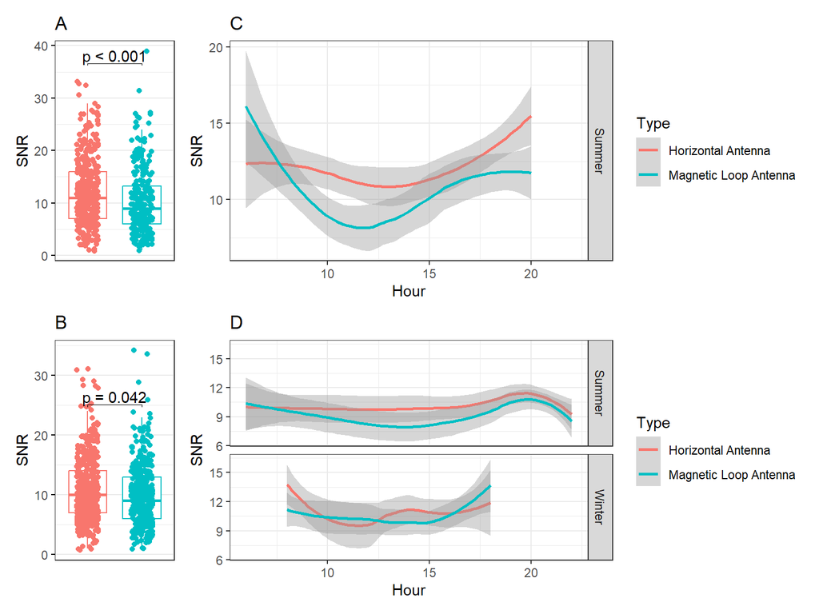

```r
DataSubValue <- as.numeric(names(table(DataSub$pair)[table(DataSub$pair) == 2]))
DataSub <- DataSub |>
  dplyr::filter(pair %in% DataSubValue) |>
  select(Type, SNR, pair, Location, FrequencyGroup, season) |>
  pivot_wider(names_from = Type,
              values_from = SNR)

test <-  t.test(DataSub$`Horizontal Antenna` -
                DataSub$`Magnetic Loop Antenna`)
print(test)
```

```
##
##  One Sample t-test
##
## data:  DataSub$`Horizontal Antenna` - DataSub$`Magnetic Loop Antenna`
## t = 9.9621, df = 393, p-value < 2.2e-16
## alternative hypothesis: true mean is not equal to 0
## 95 percent confidence interval:
##  2.073853 3.093660
## sample estimates:
## mean of x
##  2.583756
```

```r
test <-  t.test(DataSub$`Horizontal Antenna`[DataSub$FrequencyGroup == "20m band"] -
                DataSub$`Magnetic Loop Antenna`[DataSub$FrequencyGroup == "20m band"])
print(test)
```

```
##
##  One Sample t-test
##
## data:  DataSub$`Horizontal Antenna`[DataSub$FrequencyGroup == "20m band"] - DataSub$`Magnetic Loop Antenna`[DataSub$FrequencyGroup == "20m band"]
## t = 7.7736, df = 164, p-value = 7.955e-13
## alternative hypothesis: true mean is not equal to 0
## 95 percent confidence interval:
##  2.644894 4.446015
## sample estimates:
## mean of x
##  3.545455
```

```r
test <-  t.test(DataSub$`Horizontal Antenna`[DataSub$FrequencyGroup == "20m band" & DataSub$season == "Summer"] -
                DataSub$`Magnetic Loop Antenna`[DataSub$FrequencyGroup == "20m band" & DataSub$season == "Summer"])
print(test)
```

```
##
##  One Sample t-test
##
## data:  DataSub$`Horizontal Antenna`[DataSub$FrequencyGroup == "20m band" & DataSub$season == "Summer"] - DataSub$`Magnetic Loop Antenna`[DataSub$FrequencyGroup == "20m band" & DataSub$season == "Summer"]
## t = 7.7736, df = 164, p-value = 7.955e-13
## alternative hypothesis: true mean is not equal to 0
## 95 percent confidence interval:
##  2.644894 4.446015
## sample estimates:
## mean of x
##  3.545455
```

```r
test <-  t.test(DataSub$`Horizontal Antenna`[DataSub$FrequencyGroup == "40m band" & DataSub$season == "Summer"] -
                DataSub$`Magnetic Loop Antenna`[DataSub$FrequencyGroup == "40m band" & DataSub$season == "Summer"])
print(test)
```

```
##
##  One Sample t-test
##
## data:  DataSub$`Horizontal Antenna`[DataSub$FrequencyGroup == "40m band" & DataSub$season == "Summer"] - DataSub$`Magnetic Loop Antenna`[DataSub$FrequencyGroup == "40m band" & DataSub$season == "Summer"]
## t = 5.7969, df = 122, p-value = 5.412e-08
## alternative hypothesis: true mean is not equal to 0
## 95 percent confidence interval:
##  1.258129 2.563010
## sample estimates:
## mean of x
##  1.910569
```

```r
test <-  t.test(DataSub$`Horizontal Antenna`[DataSub$FrequencyGroup == "40m band"] -
                DataSub$`Magnetic Loop Antenna`[DataSub$FrequencyGroup == "40m band"])
print(test)
```

```
##
##  One Sample t-test
##
## data:  DataSub$`Horizontal Antenna`[DataSub$FrequencyGroup == "40m band"] - DataSub$`Magnetic Loop Antenna`[DataSub$FrequencyGroup == "40m band"]
## t = 6.4234, df = 228, p-value = 7.673e-10
## alternative hypothesis: true mean is not equal to 0
## 95 percent confidence interval:
##  1.310802 2.470857
## sample estimates:
## mean of x
##   1.89083
```

```r
test <-  t.test(DataSub$`Horizontal Antenna`[DataSub$FrequencyGroup == "40m band" & DataSub$season == "Winter"] -
                DataSub$`Magnetic Loop Antenna`[DataSub$FrequencyGroup == "40m band" & DataSub$season == "Winter"])
print(test)
```

```
##
##  One Sample t-test
##
## data:  DataSub$`Horizontal Antenna`[DataSub$FrequencyGroup == "40m band" & DataSub$season == "Winter"] - DataSub$`Magnetic Loop Antenna`[DataSub$FrequencyGroup == "40m band" & DataSub$season == "Winter"]
## t = 3.6631, df = 105, p-value = 0.0003924
## alternative hypothesis: true mean is not equal to 0
## 95 percent confidence interval:
##  0.8568218 2.8790272
## sample estimates:
## mean of x
##  1.867925
```

```r
DataSub <- DataSub |>
  mutate(Diff = `Horizontal Antenna` - `Magnetic Loop Antenna`)

for (s in unique(DataSub$FrequencyGroup)) {
  for (o in unique(DataSub$Location)) {
    print(s)
    print(o)
    print(t.test(DataSub$Diff[DataSub$FrequencyGroup == s & DataSub$Location == o]))
  }
}
```

```
## [1] "20m band"
## [1] "South-West"
##
##  One Sample t-test
##
## data:  DataSub$Diff[DataSub$FrequencyGroup == s & DataSub$Location == o]
## t = 4.4243, df = 12, p-value = 0.0008294
## alternative hypothesis: true mean is not equal to 0
## 95 percent confidence interval:
##  2.615738 7.691955
## sample estimates:
## mean of x
##  5.153846
##
## [1] "20m band"
## [1] "South-East"
##
##  One Sample t-test
##
## data:  DataSub$Diff[DataSub$FrequencyGroup == s & DataSub$Location == o]
## t = 5.9663, df = 103, p-value = 3.462e-08
## alternative hypothesis: true mean is not equal to 0
## 95 percent confidence interval:
##  2.362233 4.714690
## sample estimates:
## mean of x
##  3.538462
##
## [1] "20m band"
## [1] "North-East"
##
##  One Sample t-test
##
## data:  DataSub$Diff[DataSub$FrequencyGroup == s & DataSub$Location == o]
## t = 4.3601, df = 37, p-value = 9.97e-05
## alternative hypothesis: true mean is not equal to 0
## 95 percent confidence interval:
##  1.732654 4.741030
## sample estimates:
## mean of x
```

[output cut: 56 more lines]

```
##  1.811594
##
## [1] "40m band"
## [1] "North-West"
##
##  One Sample t-test
##
## data:  DataSub$Diff[DataSub$FrequencyGroup == s & DataSub$Location == o]
## t = 2.2903, df = 31, p-value = 0.02897
## alternative hypothesis: true mean is not equal to 0
## 95 percent confidence interval:
##  0.160821 2.776679
## sample estimates:
## mean of x
##   1.46875
```

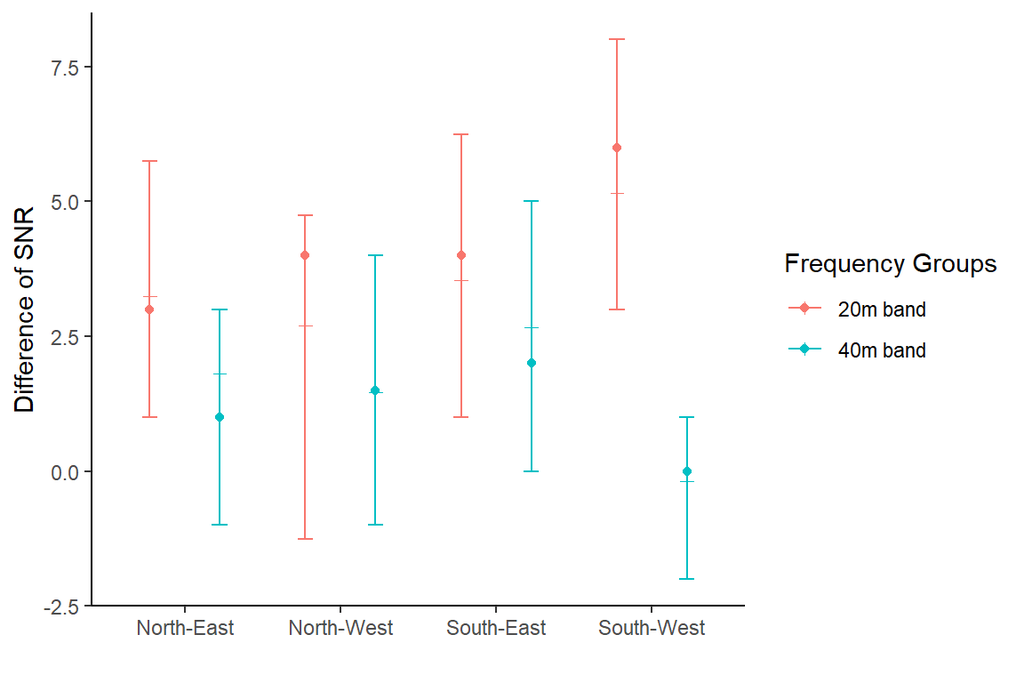

```r
DataSub <- DataSub |>
  drop_na() |>
  group_by(Location, FrequencyGroup) |>
  summarise(DiffMean = mean(Diff),
            DiffQ1 = quantile(Diff, 0.25),
            DiffQ2 = quantile(Diff, 0.5),
            DiffQ3 = quantile(Diff, 0.75),
            .groups = "drop")

ggplot(DataSub, aes(x = Location, y = DiffMean, color = FrequencyGroup)) +
  geom_point(shape = 3, position = position_dodge(0.9)) +
  geom_point(aes(y = DiffQ2), position = position_dodge(0.9)) +
  geom_errorbar(aes(ymin = DiffQ1, ymax = DiffQ3), width = 0.2, position = position_dodge(0.9))+
  theme_classic()+
  theme(legend.position = "right") +
  labs(x = "", y = "Difference of SNR", color = "Frequency Groups")
```

### Horizontal Antenna and Horizontal Antenna (QRO)

```r
DataSub <- DataClean |>
  arrange(ID, Time) |>
  dplyr::filter(Type %in% c("Horizontal Antenna", "Horizontal Antenna (QRO)"))

DataSub$pair <- NA

time_window <- 2

pair_counter <- 1
for (i in 2:nrow(DataSub)) {
  ## Same ID, Samilar time and varied type
  if (DataSub$ID[i] == DataSub$ID[i - 1] &&
      difftime(DataSub$Time[i], DataSub$Time[i - 1], units = "hours") <= time_window &&
      DataSub$Type[i] != DataSub$Type[i - 1]) {
    DataSub$pair[i] <- pair_counter
    DataSub$pair[i - 1] <- pair_counter
    pair_counter <- pair_counter + 1
  }
}

fig1 <- ggboxplot(data = DataSub[DataSub$FrequencyGroup == "20m band",],
                 x = "Type",
                 y = "SNR",
                 color = "Type",
                 palette = 'Viridis',
                 add = 'jitter',
                 ggtheme = theme_bw(),
                 legend='none',
                 xlab = "",
                 ylab = 'SNR',
                 title = 'A') +
  stat_pvalue_manual(stat.test.higher[1,],
                     label = "p",
                     tip.length = 0.01)+
  scale_x_discrete(breaks = NULL)
fig2 <- ggboxplot(data = DataSub[DataSub$FrequencyGroup == "40m band",],
                 x = "Type",
                 y = "SNR",
                 color = "Type",
                 palette = 'Viridis',
                 add = 'jitter',
                 ggtheme = theme_bw(),
                 legend='none',
                 xlab = "",
                 ylab = 'SNR',
                 title = 'B') +
  stat_pvalue_manual(stat.test.lower[1,],
                     label = "p",
                     tip.length = 0.01)+
  scale_x_discrete(breaks = NULL)
fig3 <- ggplot(dplyr::filter(DataClean,
                             Type %in% c("Horizontal Antenna", "Horizontal Antenna (QRO)") &
                               FrequencyGroup == "20m band"),
               mapping = aes(x = hour, y = SNR)) +
  geom_smooth(mapping = aes(color = Type), size = 1)+
  scale_x_continuous(limits = c(6, 22))+
  facet_grid(season ~ ., scales = "free_x") +
  theme_bw() +
  theme(legend.position = 'right') +
  labs(x = "Hour", y = "SNR", color = "Type", title = "C")
fig4 <- ggplot(dplyr::filter(DataClean,
                             Type %in% c("Horizontal Antenna", "Horizontal Antenna (QRO)") &
                               FrequencyGroup == "40m band"),
               mapping = aes(x = hour, y = SNR)) +
  geom_smooth(mapping = aes(color = Type), size = 1)+
  scale_x_continuous(limits = c(6, 22))+
  facet_grid(season ~ ., scales = "free_x") +
  theme_bw() +
  theme(legend.position = 'right') +
  labs(x = "Hour", y = "SNR", color = "Type", title = "D")

fig1 + fig3 + fig2 + fig4 + plot_layout(widths = c(1, 3))
```

`geom_smooth()` using method = ‘loess’ and formula = ‘y ~ x’

`geom_smooth()` using method = ‘loess’ and formula = ‘y ~ x’

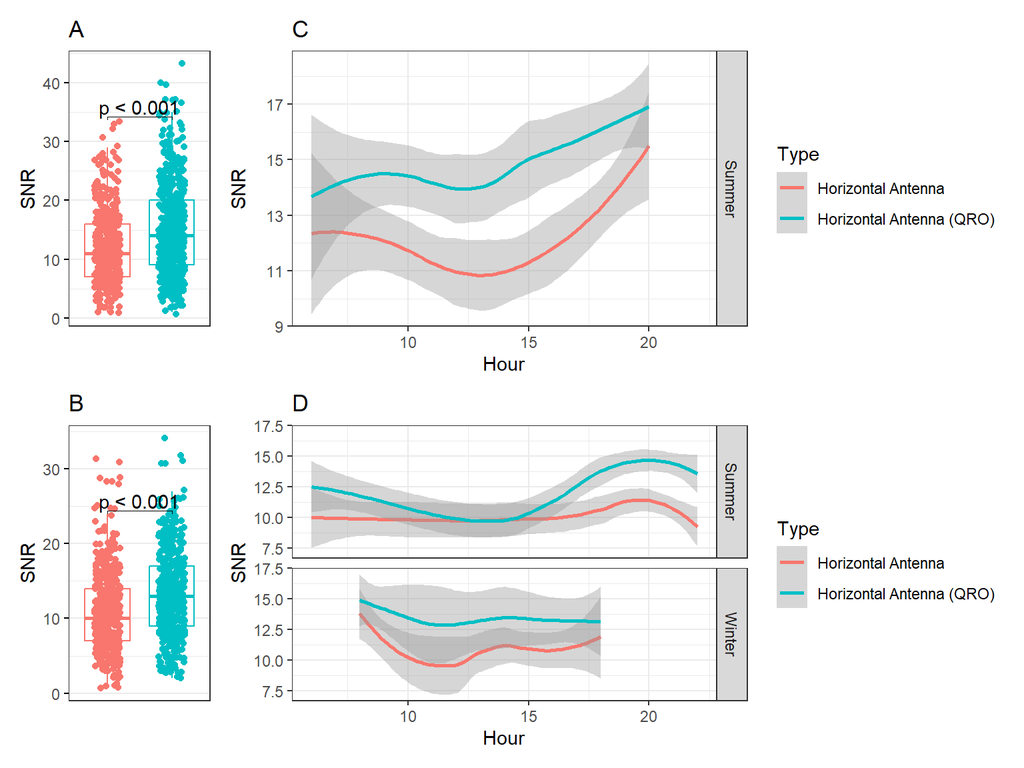

```r
DataSubValue <- as.numeric(names(table(DataSub$pair)[table(DataSub$pair) == 2]))
DataSub <- DataSub |>
  dplyr::filter(pair %in% DataSubValue) |>
  select(Type, SNR, pair, season, Location, FrequencyGroup) |>
  pivot_wider(names_from = Type,
              values_from = SNR)

test <-  t.test(DataSub$`Horizontal Antenna` -
                DataSub$`Horizontal Antenna (QRO)`)
print(test)
```

```
##
##  One Sample t-test
##
## data:  DataSub$`Horizontal Antenna` - DataSub$`Horizontal Antenna (QRO)`
## t = -20.468, df = 483, p-value < 2.2e-16
## alternative hypothesis: true mean is not equal to 0
## 95 percent confidence interval:
##  -5.097299 -4.204354
## sample estimates:
## mean of x
## -4.650826
```

```r
test <-  t.test(DataSub$`Horizontal Antenna`[DataSub$FrequencyGroup == "20m band"] -
                DataSub$`Horizontal Antenna (QRO)`[DataSub$FrequencyGroup == "20m band"])
print(test)
```

```
##
##  One Sample t-test
##
## data:  DataSub$`Horizontal Antenna`[DataSub$FrequencyGroup == "20m band"] - DataSub$`Horizontal Antenna (QRO)`[DataSub$FrequencyGroup == "20m band"]
## t = -14.586, df = 248, p-value < 2.2e-16
## alternative hypothesis: true mean is not equal to 0
## 95 percent confidence interval:
##  -5.798216 -4.418652
## sample estimates:
## mean of x
## -5.108434
```

```r
test <-  t.test(DataSub$`Horizontal Antenna`[DataSub$FrequencyGroup == "20m band" & DataSub$season == "Summer"] -
                DataSub$`Horizontal Antenna (QRO)`[DataSub$FrequencyGroup == "20m band" & DataSub$season == "Summer"])
print(test)
```

```
##
##  One Sample t-test
##
## data:  DataSub$`Horizontal Antenna`[DataSub$FrequencyGroup == "20m band" & DataSub$season == "Summer"] - DataSub$`Horizontal Antenna (QRO)`[DataSub$FrequencyGroup == "20m band" & DataSub$season == "Summer"]
## t = -14.586, df = 248, p-value < 2.2e-16
## alternative hypothesis: true mean is not equal to 0
## 95 percent confidence interval:
##  -5.798216 -4.418652
## sample estimates:
## mean of x
## -5.108434
```

```r
test <-  t.test(DataSub$`Horizontal Antenna`[DataSub$FrequencyGroup == "40m band" & DataSub$season == "Summer"] -
                DataSub$`Horizontal Antenna (QRO)`[DataSub$FrequencyGroup == "40m band" & DataSub$season == "Summer"])
print(test)
```

```
##
##  One Sample t-test
##
## data:  DataSub$`Horizontal Antenna`[DataSub$FrequencyGroup == "40m band" & DataSub$season == "Summer"] - DataSub$`Horizontal Antenna (QRO)`[DataSub$FrequencyGroup == "40m band" & DataSub$season == "Summer"]
## t = -13.852, df = 169, p-value < 2.2e-16
## alternative hypothesis: true mean is not equal to 0
## 95 percent confidence interval:
##  -4.845582 -3.636771
## sample estimates:
## mean of x
## -4.241176
```

```r
test <-  t.test(DataSub$`Horizontal Antenna`[DataSub$FrequencyGroup == "40m band"] -
                DataSub$`Horizontal Antenna (QRO)`[DataSub$FrequencyGroup == "40m band"])
print(test)
```

```
##
##  One Sample t-test
##
## data:  DataSub$`Horizontal Antenna`[DataSub$FrequencyGroup == "40m band"] - DataSub$`Horizontal Antenna (QRO)`[DataSub$FrequencyGroup == "40m band"]
## t = -14.747, df = 234, p-value < 2.2e-16
## alternative hypothesis: true mean is not equal to 0
## 95 percent confidence interval:
##  -4.722525 -3.609390
## sample estimates:
## mean of x
## -4.165957
```

```r
test <-  t.test(DataSub$`Horizontal Antenna`[DataSub$FrequencyGroup == "40m band" & DataSub$season == "Winter"] -
                DataSub$`Horizontal Antenna (QRO)`[DataSub$FrequencyGroup == "40m band" & DataSub$season == "Winter"])
print(test)
```

```
##
##  One Sample t-test
##
## data:  DataSub$`Horizontal Antenna`[DataSub$FrequencyGroup == "40m band" & DataSub$season == "Winter"] - DataSub$`Horizontal Antenna (QRO)`[DataSub$FrequencyGroup == "40m band" & DataSub$season == "Winter"]
## t = -6.2239, df = 64, p-value = 4.18e-08
## alternative hypothesis: true mean is not equal to 0
## 95 percent confidence interval:
##  -5.243269 -2.695193
## sample estimates:
## mean of x
## -3.969231
```

```r
DataSub <- DataSub |>
  mutate(Diff = `Horizontal Antenna (QRO)` - `Horizontal Antenna`)

for (s in unique(DataSub$FrequencyGroup)) {
  for (o in unique(DataSub$Location)) {
    print(s)
    print(o)
    print(t.test(DataSub$Diff[DataSub$FrequencyGroup == s & DataSub$Location == o]))
  }
}
```

```
## [1] "20m band"
## [1] "South-East"
##
##  One Sample t-test
##
## data:  DataSub$Diff[DataSub$FrequencyGroup == s & DataSub$Location == o]
## t = 9.7569, df = 136, p-value < 2.2e-16
## alternative hypothesis: true mean is not equal to 0
## 95 percent confidence interval:
##  4.085520 6.162655
## sample estimates:
## mean of x
##  5.124088
##
## [1] "20m band"
## [1] "South-West"
##
##  One Sample t-test
##
## data:  DataSub$Diff[DataSub$FrequencyGroup == s & DataSub$Location == o]
## t = 6.8331, df = 29, p-value = 1.668e-07
## alternative hypothesis: true mean is not equal to 0
## 95 percent confidence interval:
##  3.339940 6.193393
## sample estimates:
## mean of x
##  4.766667
##
## [1] "20m band"
## [1] "North-East"
##
##  One Sample t-test
##
## data:  DataSub$Diff[DataSub$FrequencyGroup == s & DataSub$Location == o]
## t = 8.3975, df = 61, p-value = 9.131e-12
## alternative hypothesis: true mean is not equal to 0
## 95 percent confidence interval:
##  4.214913 6.849603
## sample estimates:
## mean of x
```

[output cut: 56 more lines]

```
##  4.365079
##
## [1] "40m band"
## [1] "North-West"
##
##  One Sample t-test
##
## data:  DataSub$Diff[DataSub$FrequencyGroup == s & DataSub$Location == o]
## t = 6.2733, df = 27, p-value = 1.033e-06
## alternative hypothesis: true mean is not equal to 0
## 95 percent confidence interval:
##  3.629007 7.156707
## sample estimates:
## mean of x
##  5.392857
```

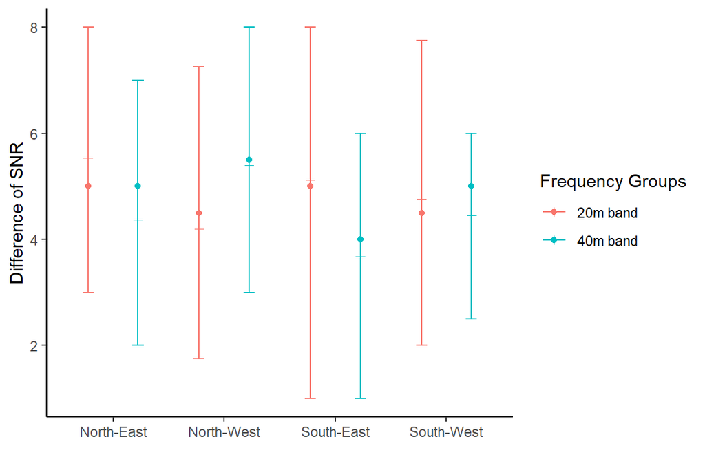

```r
DataSub <- DataSub |>
  drop_na() |>
  group_by(Location, FrequencyGroup) |>
  summarise(DiffMean = mean(Diff),
            DiffQ1 = quantile(Diff, 0.25),
            DiffQ2 = quantile(Diff, 0.5),
            DiffQ3 = quantile(Diff, 0.75),
            n = n(),
            .groups = "drop")

ggplot(DataSub, aes(x = Location, y = DiffMean, color = FrequencyGroup)) +
  geom_point(shape = 3, position = position_dodge(0.9)) +
  geom_point(aes(y = DiffQ2), position = position_dodge(0.9)) +
  geom_errorbar(aes(ymin = DiffQ1, ymax = DiffQ3), width = 0.2, position = position_dodge(0.9))+
  theme_classic()+
  theme(legend.position = "right") +
  labs(x = "", y = "Difference of SNR", color = "Frequency Groups")
```

```r
library(truncnorm)

# function ----------------------------------------------------------------

### negative log likelihood

nllt <- function(params, data) {
  mean <- params[1]
  sd <- params[2]
  alpha <- params[3]
  -sum(log(dtruncnorm(data[data >= alpha], a = alpha, mean = mean, sd = sd)))
  # -sum(log(dnorm(data[data >= alpha], mean = mean, sd = sd)))
}
nll <- function(params, data) {
  mean <- params[1]
  sd <- params[2]
  -sum(log(dnorm(data, mean = mean, sd = sd)))
}

Datalist <- DataClean |>
  dplyr::filter(TypeMag == 0) |>
  select(FrequencyGroup, Type) |>
  unique() |>
  arrange(FrequencyGroup, Type)
i <- 1

for (i in c(1, 3)) {
  Data <- DataClean |>
    dplyr::filter(FrequencyGroup == Datalist$FrequencyGroup[i] & Type == Datalist$Type[i])
  data <- Data$SNR

  ## All data
  fit <- optim(
    par = c(mean(data), sd(data)),
    nll,
    data = data,
    method = "L-BFGS-B",
    lower = c(-Inf, 0),
    upper = c(Inf, Inf)
  )

  ## All data gamma distribution
  fit2 <- MASS::fitdistr(data, "gamma")

  ## Partly data
  fit1 <- optim(
    par = c(mean(data), sd(data), 0),
    nllt,
    data = data,
    method = "L-BFGS-B",
    lower = c(-Inf, 0, 0),
    upper = c(Inf, Inf, 3)
  )

  ## plot
  outcome <- ks.test(data,
    "pnorm",
    mean = fit$par[1],
    sd = fit$par[2]
  )
  outcome1 <- ks.test(data[data >= fit1$par[3]],
    "pnorm",
    mean = fit1$par[1],
    sd = fit1$par[2]
  )
  outcome2 <- ks.test(data,
    "pgamma",
    shape = fit2$estimate[1],
    rate = fit2$estimate[2]
  )
  print(outcome)
  print(outcome1)
  print(outcome2)

  fig <- ggplot(
    data = Data,
    mapping = aes(x = SNR)
  ) +
    geom_histogram(
      mapping = aes(y = after_stat(density)),
      alpha = 0.75
    ) +
    geom_line(
      stat = "density",
      mapping = aes(color = "Density Curve")
    ) +
    stat_function(
      fun = dnorm,
      args = list(
        mean = fit$par[1],
        sd = fit$par[2]
      ),
      mapping = aes(color = "Fitted Curve (Normal)")
    ) +
    stat_function(
      fun = dgamma,
      args = list(
        shape = fit2$estimate[1],
        rate = fit2$estimate[2]
      ),
      mapping = aes(color = "Fitted Curve (Gamma)")
    ) +
    stat_function(
      fun = dtruncnorm,
      args = list(
        mean = fit1$par[1],
        sd = fit1$par[2],
        a = fit1$par[3]
      ),
      mapping = aes(color = "Fitted Curve (Truncated Normal)")
    ) +
    scale_y_continuous(
      limits = c(0, NA),
      expand = expansion(mult = c(0, 0.1))
    ) +
    theme_bw() +
    theme(
      plot.caption = element_text(hjust = 0),
      legend.position = c(0.95, 0.95),
      legend.justification = c(1, 1)
    ) +
    labs(
      color = NULL,
      caption = paste("Fitted Distribution\n",
        "Normal Distribution: (", round(fit$par[1], 3), ",", round(fit$par[2], 3), ")\n",
        "Truncated Normal Distribution: (", round(fit1$par[1], 3), ",", round(fit1$par[2], 3), ")\n",
        "Gamma Distribution: (", round(fit2$estimate[1], 3), ",", round(fit2$estimate[2], 3), ")\n",
        "Log-likelihood\n",
        "Normal Distribution: ", round(fit$value), "\n",
        "Gamma Distribution: ", -round(fit2$loglik), "\n",
        "Truncated Normal Distribution: ", round(fit1$value), "\n",
        "Kolmogorov-Smirnov\n",
        "Normal Distribution: ", round(outcome$statistic, 3),
        "; P-value=", round(outcome$p.value, 3), "\n",
        "Gamma Distribution: ", round(outcome2$statistic, 3),
        "; P-value=", round(outcome2$p.value, 3), "\n",
        "Truncated Normal Distribution: ", round(outcome1$statistic, 3),
        "; P-value=", round(outcome1$p.value, 3),
        sep = ""
      ),
      title = paste(LETTERS[i], ":", Datalist$Type[i], "in", Datalist$FrequencyGroup[i])
    )

  assign(
    paste0("fig", i),
    fig
  )
  remove(fig, data, Data, fit, fit1, outcome, outcome1)
}
```

```
##
##  Asymptotic one-sample Kolmogorov-Smirnov test
##
## data:  data
## D = 0.10255, p-value = 0.0005832
## alternative hypothesis: two-sided
##
##
##  Asymptotic one-sample Kolmogorov-Smirnov test
##
## data:  data[data >= fit1$par[3]]
## D = 0.27342, p-value < 2.2e-16
## alternative hypothesis: two-sided
##
##
##  Asymptotic one-sample Kolmogorov-Smirnov test
##
## data:  data
## D = 0.051772, p-value = 0.2507
## alternative hypothesis: two-sided
##
##
##  Asymptotic one-sample Kolmogorov-Smirnov test
##
## data:  data
## D = 0.12251, p-value = 1.139e-06
## alternative hypothesis: two-sided
##
##
##  Asymptotic one-sample Kolmogorov-Smirnov test
##
## data:  data[data >= fit1$par[3]]
## D = 0.28644, p-value < 2.2e-16
## alternative hypothesis: two-sided
##
##
##  Asymptotic one-sample Kolmogorov-Smirnov test
##
## data:  data
## D = 0.076118, p-value = 0.007771
## alternative hypothesis: two-sided
```

```r
for (i in c(2, 4)) {
  Data <- DataClean |>
    dplyr::filter(FrequencyGroup == Datalist$FrequencyGroup[i] & Type == Datalist$Type[i])
  data <- Data$SNR

  ## All data
  fit <- optim(
    par = c(mean(data), sd(data)),
    nll,
    data = data,
    method = "L-BFGS-B",
    lower = c(-Inf, 0),
    upper = c(Inf, Inf)
  )
  ## Alll data gamma distribution
  fit2 <- MASS::fitdistr(data, "gamma")

  ## plot
  outcome <- ks.test(data,
    "pnorm",
    mean = fit$par[1],
    sd = fit$par[2]
  )
  outcome2 <- ks.test(data,
    "pgamma",
    shape = fit2$estimate[1],
    rate = fit2$estimate[2]
  )
  print(outcome)
  print(outcome2)

  fig <- ggplot(
    data = Data,
    mapping = aes(x = SNR)
  ) +
    geom_histogram(
      mapping = aes(y = after_stat(density)),
      alpha = 0.75
    ) +
    geom_line(
      stat = "density",
      mapping = aes(color = "Density Curve")
    ) +
    stat_function(
      fun = dnorm,
      args = list(
        mean = fit$par[1],
        sd = fit$par[2]
      ),
      mapping = aes(color = "Fitted Curve (Normal)")
    ) +
    stat_function(
      fun = dgamma,
      args = list(
        shape = fit2$estimate[1],
        rate = fit2$estimate[2]
      ),
      mapping = aes(color = "Fitted Curve (Gamma)")
    ) +
    scale_y_continuous(
      limits = c(0, NA),
      expand = expansion(mult = c(0, 0.1))
    ) +
    theme_bw() +
    theme(
      plot.caption = element_text(hjust = 0),
      legend.position = c(0.95, 0.95),
      legend.justification = c(1, 1)
    ) +
    labs(
      color = NULL,
      caption = paste("Fitted Distribution\n",
        "Normal Distribution: (", round(fit$par[1], 3), ",", round(fit$par[2], 3), ")\n",
        "Gamma Distribution: (", round(fit2$estimate[1], 3), ",", round(fit2$estimate[2], 3), ")\n",
        "Log-likelihood\n",
        "Normal Distribution: ", round(fit$value), "\n",
        "Gamma Distribution: ", -round(fit2$loglik), "\n",
        "Kolmogorov-Smirnov\n",
        "Normal Distribution: ", round(outcome$statistic, 3),
        "; P-value=", round(outcome$p.value, 3), "\n",
        "Gamma Distribution: ", round(outcome2$statistic, 3),
        "; P-value=", round(outcome2$p.value, 3),
        sep = ""
      ),
      title = paste(LETTERS[i], ":", Datalist$Type[i], "in", Datalist$FrequencyGroup[i])
    )

  assign(
    paste0("fig", i),
    fig
  )
  remove(fig, data, Data, fit, fit1, outcome, outcome1)
}
```

```
##
##  Asymptotic one-sample Kolmogorov-Smirnov test
##
## data:  data
## D = 0.087936, p-value = 0.0003208
## alternative hypothesis: two-sided
##
##
##  Asymptotic one-sample Kolmogorov-Smirnov test
##
## data:  data
## D = 0.051029, p-value = 0.1055
## alternative hypothesis: two-sided
##
##
##  Asymptotic one-sample Kolmogorov-Smirnov test
##
## data:  data
## D = 0.072382, p-value = 0.01499
## alternative hypothesis: two-sided
##
##
##  Asymptotic one-sample Kolmogorov-Smirnov test
##
## data:  data
## D = 0.064078, p-value = 0.0432
## alternative hypothesis: two-sided
```

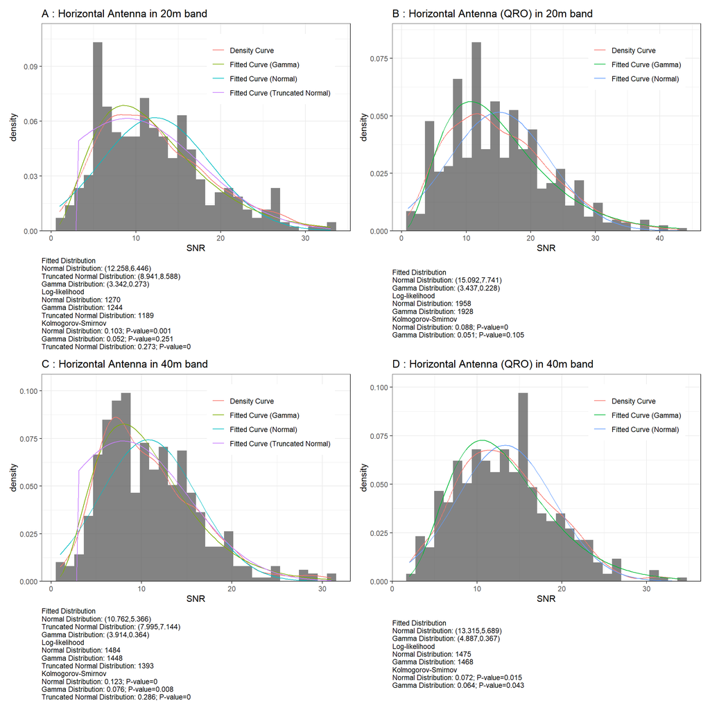

```r
fig1 + fig2 + fig3 + fig4
```

```r
ggsave("./Distribution_p.png",
  width = 10,
  height = 10
)
```

## Adjusted by station

Mixed Design ANOVA

Consider the samples not independent, because some samples collect from the same station.

```r
model <- aov(SNR ~ Type + Error(ID), data = DataClean)
summary(model)
```

```
##
## Error: ID
##            Df Sum Sq Mean Sq F value   Pr(>F)
## Type        2   5513  2756.4   16.33 6.59e-07 ***
## Residuals 106  17895   168.8
## ---
## Signif. codes:  0 '***' 0.001 '**' 0.01 '*' 0.05 '.' 0.1 ' ' 1
##
## Error: Within
##             Df Sum Sq Mean Sq F value Pr(>F)
## Type         2  12547    6274   211.5 <2e-16 ***
## Residuals 2475  73417      30
## ---
## Signif. codes:  0 '***' 0.001 '**' 0.01 '*' 0.05 '.' 0.1 ' ' 1
```

The difference between groups was still statistically significant, after adjusted by station.

Multiple linear regression (Quantitative difference)

```r
model <- lm(SNR ~ TypeQro + TypeMag + ID,
            data = DataClean)
summary(model)
```

```
##
## Call:
## lm(formula = SNR ~ TypeQro + TypeMag + ID, data = DataClean)
##
## Residuals:
##      Min       1Q   Median       3Q      Max
## -16.0198  -3.4733  -0.3852   2.8568  26.2101
##
## Coefficients:
##               Estimate Std. Error t value Pr(>|t|)
## (Intercept)  3.370e+00  5.452e+00   0.618  0.53662
## TypeQro      3.630e+00  2.563e-01  14.164  < 2e-16 ***
## TypeMag     -1.831e+00  2.831e-01  -6.468 1.19e-10 ***
## IDBD8CS      4.569e+00  5.777e+00   0.791  0.42910
## IDBH4RXP     3.000e+00  7.702e+00   0.389  0.69695
## IDCT1EYQ     1.134e+01  5.530e+00   2.050  0.04043 *
## IDDC8YZ      1.134e+01  5.502e+00   2.061  0.03941 *
## IDDD5XX      5.756e+00  5.670e+00   1.015  0.31014
## IDDE1LON     4.007e+00  5.529e+00   0.725  0.46869
## IDDF2CK      9.790e+00  5.482e+00   1.786  0.07423 .
## IDDF7GB      5.000e+00  5.502e+00   0.909  0.36358
## IDDJ2BC      5.792e+00  5.528e+00   1.048  0.29484
## IDDJ9FBA     1.630e+00  7.707e+00   0.212  0.83248
## IDDK0TE      6.941e+00  5.689e+00   1.220  0.22256
## IDDK9IP      3.595e+00  5.496e+00   0.654  0.51301
## IDDL0LA      4.956e+00  5.779e+00   0.858  0.39120
## IDDL0PF      6.326e+00  5.519e+00   1.146  0.25183
## IDDL1HWS     3.316e+00  5.555e+00   0.597  0.55068
## IDDL8LAS     5.627e+00  5.502e+00   1.023  0.30657
## IDDL8TG      7.847e+00  5.511e+00   1.424  0.15462
## IDDL9GTB     8.983e+00  5.511e+00   1.630  0.10327
## IDDM5GG      6.968e+00  5.493e+00   1.269  0.20473
## IDDM6EE      4.888e+00  5.541e+00   0.882  0.37781
## IDDM7EE      9.554e+00  5.562e+00   1.718  0.08596 .
## IDDO4DXA     3.506e+00  5.742e+00   0.611  0.54151
## IDDR4W       9.055e+00  5.565e+00   1.627  0.10385
## IDEA1DAV     7.451e+00  5.496e+00   1.356  0.17530
## IDEA1RX      2.462e+00  7.707e+00   0.319  0.74947
## IDEA1URA     1.070e+00  5.570e+00   0.192  0.84762
## IDEA2CW      1.375e+00  5.555e+00   0.247  0.80456
```

[output cut: 72 more lines]

```
## IDVE2WU      1.004e+01  5.653e+00   1.776  0.07582 .
## IDVR2FUN    -2.756e-12  6.670e+00   0.000  1.00000
## IDW1NT       6.164e+00  5.547e+00   1.111  0.26659
## IDW3UA       9.158e+00  6.090e+00   1.504  0.13276
## IDW4KAZ      1.000e+00  7.702e+00   0.130  0.89671
## IDW8WWV      1.000e+00  7.702e+00   0.130  0.89671
## IDWC2L      -3.000e+00  7.702e+00  -0.389  0.69695
## IDWZ7I       2.101e-01  6.290e+00   0.033  0.97336
## IDYO4RDW     6.315e+00  6.672e+00   0.947  0.34396
## ---
## Signif. codes:  0 '***' 0.001 '**' 0.01 '*' 0.05 '.' 0.1 ' ' 1
##
## Residual standard error: 5.446 on 2475 degrees of freedom
## Multiple R-squared:  0.3287, Adjusted R-squared:  0.2989
## F-statistic: 11.02 on 110 and 2475 DF,  p-value: < 2.2e-16
```

not independent

```r
library(lme4)
library(car)
model <- lmer(SNR ~ TypeQro + (1 | ID), data = dplyr::filter(DataClean, TypeMag == 0))
summary(model)
```

```
## Linear mixed model fit by REML ['lmerMod']
## Formula: SNR ~ TypeQro + (1 | ID)
##    Data: dplyr::filter(DataClean, TypeMag == 0)
##
## REML criterion at convergence: 12109.8
##
## Scaled residuals:
##     Min      1Q  Median      3Q     Max
## -2.7770 -0.6647 -0.0902  0.5513  4.7338
##
## Random effects:
##  Groups   Name        Variance Std.Dev.
##  ID       (Intercept) 11.32    3.365
##  Residual             31.52    5.614
## Number of obs: 1898, groups:  ID, 108
##
## Fixed effects:
##             Estimate Std. Error t value
## (Intercept)  10.0027     0.4136   24.18
## TypeQro       3.5185     0.2635   13.35
##
## Correlation of Fixed Effects:
##         (Intr)
## TypeQro -0.366
```

```r
Anova(model)
```

```
## Analysis of Deviance Table (Type II Wald chisquare tests)
##
## Response: SNR
##          Chisq Df Pr(>Chisq)
## TypeQro 178.27  1  < 2.2e-16 ***
## ---
## Signif. codes:  0 '***' 0.001 '**' 0.01 '*' 0.05 '.' 0.1 ' ' 1
```

```r
model <- lmer(SNR ~ TypeMag + (1 | ID), data = dplyr::filter(DataClean, TypeQro == 0))
summary(model)
```

```
## Linear mixed model fit by REML ['lmerMod']
## Formula: SNR ~ TypeMag + (1 | ID)
##    Data: dplyr::filter(DataClean, TypeQro == 0)
##
## REML criterion at convergence: 9603.7
##
## Scaled residuals:
##     Min      1Q  Median      3Q     Max
## -2.4562 -0.6262 -0.1103  0.5063  5.0745
##
## Random effects:
##  Groups   Name        Variance Std.Dev.
##  ID       (Intercept)  7.598   2.756
##  Residual             25.900   5.089
## Number of obs: 1554, groups:  ID, 95
##
## Fixed effects:
##             Estimate Std. Error t value
## (Intercept)  10.6680     0.3611   29.55
## TypeMag      -1.7196     0.2654   -6.48
##
## Correlation of Fixed Effects:
##         (Intr)
## TypeMag -0.307
```

```r
Anova(model)
```

```
## Analysis of Deviance Table (Type II Wald chisquare tests)
##
## Response: SNR
##          Chisq Df Pr(>Chisq)
## TypeMag 41.995  1  9.148e-11 ***
## ---
## Signif. codes:  0 '***' 0.001 '**' 0.01 '*' 0.05 '.' 0.1 ' ' 1
```

## Adjusted by station and periods

```r
model <- lmer(SNR ~ TypeQro + (1 | ID) + (1 | periods), data = dplyr::filter(DataClean, TypeMag == 0))
summary(model)
```

```
## Linear mixed model fit by REML ['lmerMod']
## Formula: SNR ~ TypeQro + (1 | ID) + (1 | periods)
##    Data: dplyr::filter(DataClean, TypeMag == 0)
##
## REML criterion at convergence: 12086.8
##
## Scaled residuals:
##     Min      1Q  Median      3Q     Max
## -2.7743 -0.6436 -0.0936  0.5200  4.8659
##
## Random effects:
##  Groups   Name        Variance Std.Dev.
##  ID       (Intercept) 11.9001  3.4496
##  periods  (Intercept)  0.7348  0.8572
##  Residual             30.9689  5.5650
## Number of obs: 1898, groups:  ID, 108; periods, 3
##
## Fixed effects:
##             Estimate Std. Error t value
## (Intercept)   9.9940     0.6494   15.39
## TypeQro       3.4750     0.2616   13.29
##
## Correlation of Fixed Effects:
##         (Intr)
## TypeQro -0.233
```

```r
Anova(model)
```

```
## Analysis of Deviance Table (Type II Wald chisquare tests)
##
## Response: SNR
##         Chisq Df Pr(>Chisq)
## TypeQro 176.5  1  < 2.2e-16 ***
## ---
## Signif. codes:  0 '***' 0.001 '**' 0.01 '*' 0.05 '.' 0.1 ' ' 1
```

```r
model <- lmer(SNR ~ TypeMag + (1 | ID) + (1 | periods), data = dplyr::filter(DataClean, TypeQro == 0))
summary(model)
```

```
## Linear mixed model fit by REML ['lmerMod']
## Formula: SNR ~ TypeMag + (1 | ID) + (1 | periods)
##    Data: dplyr::filter(DataClean, TypeQro == 0)
##
## REML criterion at convergence: 9582.1
##
## Scaled residuals:
##     Min      1Q  Median      3Q     Max
## -2.5478 -0.6487 -0.1356  0.4979  5.2312
##
## Random effects:
##  Groups   Name        Variance Std.Dev.
##  ID       (Intercept)  8.0218  2.8323
##  periods  (Intercept)  0.6692  0.8181
##  Residual             25.3782  5.0377
## Number of obs: 1554, groups:  ID, 95; periods, 3
##
## Fixed effects:
##             Estimate Std. Error t value
## (Intercept)  10.7143     0.5987   17.90
## TypeMag      -1.7779     0.2630   -6.76
##
## Correlation of Fixed Effects:
##         (Intr)
## TypeMag -0.183
```

```r
Anova(model)
```

```
## Analysis of Deviance Table (Type II Wald chisquare tests)
##
## Response: SNR
##          Chisq Df Pr(>Chisq)
## TypeMag 45.702  1  1.377e-11 ***
## ---
## Signif. codes:  0 '***' 0.001 '**' 0.01 '*' 0.05 '.' 0.1 ' ' 1
```

## Adjusted by distance and direction

```r
model <- lmer(SNR ~ TypeQro + (1 | Distance) + (1 | Location),
              data = dplyr::filter(DataClean, TypeMag == 0 & FrequencyGroup == "20m band"))
summary(model)
```

```
## Linear mixed model fit by REML ['lmerMod']
## Formula: SNR ~ TypeQro + (1 | Distance) + (1 | Location)
##    Data: dplyr::filter(DataClean, TypeMag == 0 & FrequencyGroup == "20m band")
##
## REML criterion at convergence: 6249.1
##
## Scaled residuals:
##     Min      1Q  Median      3Q     Max
## -2.7651 -0.6876 -0.1080  0.5600  4.0118
##
## Random effects:
##  Groups   Name        Variance Std.Dev.
##  Distance (Intercept) 16.258   4.032
##  Location (Intercept)  3.608   1.899
##  Residual             36.463   6.038
## Number of obs: 952, groups:  Distance, 84; Location, 4
##
## Fixed effects:
##             Estimate Std. Error t value
## (Intercept)  10.4511     1.1713   8.922
## TypeQro       3.8034     0.4062   9.363
##
## Correlation of Fixed Effects:
##         (Intr)
## TypeQro -0.227
```

```r
Anova(model)
```

```
## Analysis of Deviance Table (Type II Wald chisquare tests)
##
## Response: SNR
##          Chisq Df Pr(>Chisq)
## TypeQro 87.659  1  < 2.2e-16 ***
## ---
## Signif. codes:  0 '***' 0.001 '**' 0.01 '*' 0.05 '.' 0.1 ' ' 1
```

```r
model <- lmer(SNR ~ TypeQro + (1 | Distance) + (1 | Location),
              data = dplyr::filter(DataClean, TypeMag == 0 & FrequencyGroup == "40m band"))
```

boundary (singular) fit: see help(‘isSingular’)

```r
summary(model)
```

```
## Linear mixed model fit by REML ['lmerMod']
## Formula: SNR ~ TypeQro + (1 | Distance) + (1 | Location)
##    Data: dplyr::filter(DataClean, TypeMag == 0 & FrequencyGroup == "40m band")
##
## REML criterion at convergence: 5699.1
##
## Scaled residuals:
##     Min      1Q  Median      3Q     Max
## -3.2652 -0.6194 -0.0456  0.5935  4.5142
##
## Random effects:
##  Groups   Name        Variance Std.Dev.
##  Distance (Intercept)  9.093   3.015
##  Location (Intercept)  0.000   0.000
##  Residual             21.475   4.634
## Number of obs: 946, groups:  Distance, 74; Location, 4
##
## Fixed effects:
##             Estimate Std. Error t value
## (Intercept)   9.5046     0.4440   21.41
## TypeQro       3.1487     0.3078   10.23
##
## Correlation of Fixed Effects:
##         (Intr)
## TypeQro -0.351
## optimizer (nloptwrap) convergence code: 0 (OK)
## boundary (singular) fit: see help('isSingular')
```

```r
Anova(model)
```

```
## Analysis of Deviance Table (Type II Wald chisquare tests)
##
## Response: SNR
##          Chisq Df Pr(>Chisq)
## TypeQro 104.64  1  < 2.2e-16 ***
## ---
## Signif. codes:  0 '***' 0.001 '**' 0.01 '*' 0.05 '.' 0.1 ' ' 1
```

```r
model <- lmer(SNR ~ TypeMag + (1 | Distance) + (1 | Location),
              data = dplyr::filter(DataClean, TypeQro == 0 & FrequencyGroup == "20m band"))
```

boundary (singular) fit: see help(‘isSingular’)

```r
summary(model)
```

```
## Linear mixed model fit by REML ['lmerMod']
## Formula: SNR ~ TypeMag + (1 | Distance) + (1 | Location)
##    Data: dplyr::filter(DataClean, TypeQro == 0 & FrequencyGroup == "20m band")
##
## REML criterion at convergence: 4171.6
##
## Scaled residuals:
##     Min      1Q  Median      3Q     Max
## -2.3576 -0.6203 -0.1070  0.4843  4.5698
##
## Random effects:
##  Groups   Name        Variance Std.Dev.
##  Distance (Intercept)  8.907   2.984
##  Location (Intercept)  0.000   0.000
##  Residual             31.891   5.647
## Number of obs: 651, groups:  Distance, 67; Location, 4
##
## Fixed effects:
##             Estimate Std. Error t value
## (Intercept)  11.7235     0.5074   23.11
## TypeMag      -2.2031     0.4580   -4.81
##
## Correlation of Fixed Effects:
##         (Intr)
## TypeMag -0.350
## optimizer (nloptwrap) convergence code: 0 (OK)
## boundary (singular) fit: see help('isSingular')
```

```r
Anova(model)
```

```
## Analysis of Deviance Table (Type II Wald chisquare tests)
##
## Response: SNR
##         Chisq Df Pr(>Chisq)
## TypeMag 23.14  1  1.507e-06 ***
## ---
## Signif. codes:  0 '***' 0.001 '**' 0.01 '*' 0.05 '.' 0.1 ' ' 1
```

```r
model <- lmer(SNR ~ TypeMag + (1 | Distance) + (1 | Location),
              data = dplyr::filter(DataClean, TypeQro == 0 & FrequencyGroup == "40m band"))
```

boundary (singular) fit: see help(‘isSingular’)

```r
summary(model)
```

```
## Linear mixed model fit by REML ['lmerMod']
## Formula: SNR ~ TypeMag + (1 | Distance) + (1 | Location)
##    Data: dplyr::filter(DataClean, TypeQro == 0 & FrequencyGroup == "40m band")
##
## REML criterion at convergence: 5325
##
## Scaled residuals:
##     Min      1Q  Median      3Q     Max
## -2.9307 -0.6290 -0.0972  0.5327  5.6573
##
## Random effects:
##  Groups   Name        Variance Std.Dev.
##  Distance (Intercept)  8.356   2.891
##  Location (Intercept)  0.000   0.000
##  Residual             18.902   4.348
## Number of obs: 903, groups:  Distance, 71; Location, 4
##
## Fixed effects:
##             Estimate Std. Error t value
## (Intercept)   9.6988     0.4289  22.612
## TypeMag      -1.3399     0.2982  -4.493
##
## Correlation of Fixed Effects:
##         (Intr)
## TypeMag -0.302
## optimizer (nloptwrap) convergence code: 0 (OK)
## boundary (singular) fit: see help('isSingular')
```

```r
Anova(model)
```

```
## Analysis of Deviance Table (Type II Wald chisquare tests)
##
## Response: SNR
##          Chisq Df Pr(>Chisq)
## TypeMag 20.184  1  7.033e-06 ***
## ---
## Signif. codes:  0 '***' 0.001 '**' 0.01 '*' 0.05 '.' 0.1 ' ' 1
```

```r
model <- lmer(SNR ~ TypeQro + (1 | DistanceGroup) + (1 | periods) + (1 | Location), data = dplyr::filter(DataClean, TypeMag == 0))
summary(model)
```

```
## Linear mixed model fit by REML ['lmerMod']
## Formula: SNR ~ TypeQro + (1 | DistanceGroup) + (1 | periods) + (1 | Location)
##    Data: dplyr::filter(DataClean, TypeMag == 0)
##
## REML criterion at convergence: 12433.4
##
## Scaled residuals:
##     Min      1Q  Median      3Q     Max
## -2.2853 -0.7214 -0.1307  0.6013  4.7121
##
## Random effects:
##  Groups        Name        Variance Std.Dev.
##  DistanceGroup (Intercept)  2.3862  1.5447
##  Location      (Intercept)  0.2505  0.5005
##  periods       (Intercept)  0.3798  0.6163
##  Residual                  40.5543  6.3682
## Number of obs: 1898, groups:  DistanceGroup, 5; Location, 4; periods, 3
##
## Fixed effects:
##             Estimate Std. Error t value
## (Intercept)  10.9174     0.8552   12.77
## TypeQro       2.9654     0.2961   10.02
##
## Correlation of Fixed Effects:
##         (Intr)
## TypeQro -0.196
```

```r
Anova(model)
```

```
## Analysis of Deviance Table (Type II Wald chisquare tests)
##
## Response: SNR
##         Chisq Df Pr(>Chisq)
## TypeQro 100.3  1  < 2.2e-16 ***
## ---
## Signif. codes:  0 '***' 0.001 '**' 0.01 '*' 0.05 '.' 0.1 ' ' 1
```

```r
model <- lmer(SNR ~ TypeMag + (1 | DistanceGroup) + (1 | periods) + (1 | Location), data = dplyr::filter(DataClean, TypeQro == 0))
summary(model)
```

```
## Linear mixed model fit by REML ['lmerMod']
## Formula: SNR ~ TypeMag + (1 | DistanceGroup) + (1 | periods) + (1 | Location)
##    Data: dplyr::filter(DataClean, TypeQro == 0)
##
## REML criterion at convergence: 9802.8
##
## Scaled residuals:
##     Min      1Q  Median      3Q     Max
## -2.1309 -0.7313 -0.1272  0.5357  5.0185
##
## Random effects:
##  Groups        Name        Variance Std.Dev.
##  DistanceGroup (Intercept)  2.0464  1.4305
##  Location      (Intercept)  1.1660  1.0798
##  periods       (Intercept)  0.3038  0.5512
##  Residual                  31.6904  5.6294
## Number of obs: 1554, groups:  DistanceGroup, 5; Location, 4; periods, 3
##
## Fixed effects:
##             Estimate Std. Error t value
## (Intercept)  10.9395     0.9322  11.735
## TypeMag      -1.2785     0.2893  -4.419
##
## Correlation of Fixed Effects:
##         (Intr)
## TypeMag -0.128
```

```r
Anova(model)
```

```
## Analysis of Deviance Table (Type II Wald chisquare tests)
##
## Response: SNR
##          Chisq Df Pr(>Chisq)
## TypeMag 19.531  1  9.897e-06 ***
## ---
## Signif. codes:  0 '***' 0.001 '**' 0.01 '*' 0.05 '.' 0.1 ' ' 1
```

## Design model to predict SNR

```r
DataClean <- DataClean |>
  mutate(DistanceGroup = cut(Distance,
                             breaks = c(0, 500, 1000, 1300, 3000, 10000)))
for (s in unique(DataClean$season)) {
  for (d in unique(DataClean$DistanceGroup)) {
    DataSub <- DataClean |>
      filter(season == s & DistanceGroup == d)
    model <- lmer(SNR ~ TypeQro + TypeMag + as.factor(hour) + (1|ID), data = DataClean)
    print(paste(s, d))
    print(summary(model))
  }
}
```

```
## [1] "Winter (1.3e+03,3e+03]"
## Linear mixed model fit by REML ['lmerMod']
## Formula: SNR ~ TypeQro + TypeMag + as.factor(hour) + (1 | ID)
##    Data: DataClean
##
## REML criterion at convergence: 16123
##
## Scaled residuals:
##     Min      1Q  Median      3Q     Max
## -2.8431 -0.6355 -0.0953  0.5220  4.9002
##
## Random effects:
##  Groups   Name        Variance Std.Dev.
##  ID       (Intercept) 12.14    3.484
##  Residual             27.77    5.269
## Number of obs: 2586, groups:  ID, 109
##
## Fixed effects:
##                   Estimate Std. Error t value
## (Intercept)         5.3302     0.9050   5.890
## TypeQro             3.4205     0.2480  13.793
## TypeMag            -1.8823     0.2743  -6.862
## as.factor(hour)7    6.3932     0.9348   6.839
## as.factor(hour)8    5.3783     1.0019   5.368
## as.factor(hour)9    3.9191     0.9111   4.301
## as.factor(hour)10   4.4530     0.8953   4.974
## as.factor(hour)11   2.0664     0.9771   2.115
## as.factor(hour)12   3.4977     0.8973   3.898
## as.factor(hour)13   2.7881     0.9073   3.073
## as.factor(hour)14   2.7051     0.9769   2.769
## as.factor(hour)15   3.7201     0.8992   4.137
## as.factor(hour)16   4.7147     0.8830   5.339
## as.factor(hour)17   4.3867     0.8879   4.940
## as.factor(hour)18   5.9793     0.9251   6.463
## as.factor(hour)19   4.6889     0.8945   5.242
## as.factor(hour)20   6.6751     0.8591   7.770
## as.factor(hour)21   5.0158     0.9792   5.122
## as.factor(hour)22   3.6850     0.9648   3.819
## [1] "Winter (500,1e+03]"
## Linear mixed model fit by REML ['lmerMod']
```

[output cut: 325 more lines]

```
## as.factor(hour)8    5.3783     1.0019   5.368
## as.factor(hour)9    3.9191     0.9111   4.301
## as.factor(hour)10   4.4530     0.8953   4.974
## as.factor(hour)11   2.0664     0.9771   2.115
## as.factor(hour)12   3.4977     0.8973   3.898
## as.factor(hour)13   2.7881     0.9073   3.073
## as.factor(hour)14   2.7051     0.9769   2.769
## as.factor(hour)15   3.7201     0.8992   4.137
## as.factor(hour)16   4.7147     0.8830   5.339
## as.factor(hour)17   4.3867     0.8879   4.940
## as.factor(hour)18   5.9793     0.9251   6.463
## as.factor(hour)19   4.6889     0.8945   5.242
## as.factor(hour)20   6.6751     0.8591   7.770
## as.factor(hour)21   5.0158     0.9792   5.122
## as.factor(hour)22   3.6850     0.9648   3.819
```